# Effect of animal manure, crop type, climate zone, and soil attributes on greenhouse gas emissions from agricultural soils—A global meta-analysis - ScienceDirect

[Advanced](https://www.sciencedirect.com/search)

## Outline

1. Highlights
2. Abstract
3. Keywords
4. 1. Introduction
5. 2. Materials and methods
6. 3. Results and discussion
7. 4. Limitations and concluding remarks
8. Declaration of competing interest
9. Acknowledgments
10. Appendix A. Supplementary data
11. References

## Figures (6)

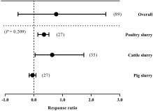

## Tables (1)

1. Table 1

## Extras (1)

1. Multimedia component 1

## [Journal of Cleaner Production](https://www.sciencedirect.com/science/journal/09596526)

[Volume 278](https://www.sciencedirect.com/science/journal/09596526/278/supp/C), 1 January 2021, 124019

# Review Effect of animal manure, crop type, climate zone, and soil attributes on greenhouse gas emissions from agricultural soils—A global meta-analysis

[AwaisShakoor<sup>a</sup>](https://www.sciencedirect.com/science/article/pii/S0959652620340646#!)[SabaShakoor<sup>b</sup>](https://www.sciencedirect.com/science/article/pii/S0959652620340646#!)[AbdulRehman<sup>c</sup>](https://www.sciencedirect.com/science/article/pii/S0959652620340646#!)[FatimaAshraf<sup>d</sup>](https://www.sciencedirect.com/science/article/pii/S0959652620340646#!)[MuhammadAbdullah<sup>e</sup>](https://www.sciencedirect.com/science/article/pii/S0959652620340646#!)[Sher MuhammadShahzad<sup>f</sup>](https://www.sciencedirect.com/science/article/pii/S0959652620340646#!)[Taimoor HassanFarooq<sup>g</sup><sup>h</sup>](https://www.sciencedirect.com/science/article/pii/S0959652620340646#!)[MuhammadAshraf<sup>i</sup>](https://www.sciencedirect.com/science/article/pii/S0959652620340646#!)[Muhammad AamirManzoor<sup>e</sup>](https://www.sciencedirect.com/science/article/pii/S0959652620340646#!)[Muhammad MohsinAltaf<sup>j</sup>](https://www.sciencedirect.com/science/article/pii/S0959652620340646#!)[Muhammad AhsanAltaf<sup>k</sup>](https://www.sciencedirect.com/science/article/pii/S0959652620340646#!)

https://doi.org/10.1016/j.jclepro.2020.124019[Get rights and content](https://s100.copyright.com/AppDispatchServlet?publisherName=ELS&contentID=S0959652620340646&orderBeanReset=true)

## Highlights

**•**

Manure application, particularly poultry manure significantly increased GHGs emissions from croplands.

**•**

Forty-eight publications were used to conduct a global meta-analysis study.

**•**

Overall, manure application had no effect on GWP because confidence interval overlapped with zero.

**•**

Soil physiochemical properties had a strong impact on the response of GHGs emissions to manure application.

## Keywords

meta-Analysis

Animal manure

GHGs emissions

Soil attributes

Crop type

## 1. Introduction

Emissions of GHGs like carbon dioxide (CO<sub>2</sub>), methane (CH<sub>4</sub>), and nitrous oxide (N<sub>2</sub>O) from the terrestrial environment have been renowned as the main contributor to global warming (Ren et al., 2017). Agriculture was seen as the first evidence of increased human-made greenhouse gas emissions into the atmosphere (Paustian et al., 2016). It contributes almost 10–14% of total global GHG emissions, which includes 50–60% of N<sub>2</sub>O and CH<sub>4</sub> that are directly linked with agricultural soil and its inputs like manure application and synthetic fertilizers (Shakoor et al., 2020b).

Application of animal manure to agricultural lands as organic fertilizer improved crop productivity, soil fertility and boosts organic carbon (OC) reserves in the soil, but also affects GHGs emissions (Zhou et al., 2017b). Globally, 7.0 billion tons of animal manure is used annually for agricultural lands (Thangarajan et al., 2013). The total quantity of produced manure, for each type of animal, can be calculated as an average between the quantity of manure produced per animal, and the number of animals (IPCC, 2006). Animal manure contributes up to 37% of global GHGs emissions (Vac et al., 2013). Soil texture (Oertel et al., 2016), soil pH (Wu et al., 2018), water filled pore space (WFPS) (Säurich et al., 2019), crop type (Severin et al., 2015) and crop duration (Tongwane et al., 2016) have also been documented important factors of CO<sub>2</sub>, CH<sub>4</sub> and N<sub>2</sub>O emissions from the terrestrial environment.

Atmospheric CO<sub>2</sub> plays an important role in the global carbon cycle in the atmospheric system. Human activities such as the burning of fossil fuel and deforestation significantly increased the CO<sub>2</sub> concentration in the atmosphere from around 280 to 387 ppm (parts per million) and, recently, have even exceeded 400 ppm (parts per million). This CO<sub>2</sub> concentration is projected to increase considerably by 2100 (Goldman et al., 2017). In the earth system, this global carbon cycle contributes to a large amount of carbon, which is connected through the exchange of carbon fluxes (Ciais et al., 2013). The terrestrial environment is intimately linked to atmospheric CO<sub>2</sub> levels by the sequestration of carbon in the soil and biomass, which is emitted by the decomposition of organic manure (Drigo et al., 2008). In a research study, it was found that the application of animal manure potentially enhances the carbon content in the soil and then converts into a net CO<sub>2</sub> sink (Gattinger et al., 2012).

Following CO<sub>2</sub> and CH<sub>4</sub>, N<sub>2</sub>O is the third most important GHG, contributing up to 6% in global warming. While, N<sub>2</sub>O has 298 times more GWP compared to CO<sub>2</sub> and also favors ozone (O<sub>3</sub>) destruction (Charles et al., 2017). The emission of N<sub>2</sub>O from agricultural sources is considered to be one of the main contributors to the global warming budget. Agricultural lands approximately contribute up to 68% in the atmospheric N<sub>2</sub>O emissions (Shakoor et al., 2018). Application of animal manure cannot only enhance soil pH (Whalen et al., 2000) but also improved soil aggregation, porosity as well as hydraulic conductivity (Haynes and Naidu, 1998), which can control different biotic and abiotic processes leading N<sub>2</sub>O production in soils (Shakoor et al., 2016). Several studies show the effects of different animal manures and synthetic fertilizers on N<sub>2</sub>O emission from agricultural lands, indicating, that different manures and dung management practices, for example, manure storage, animal houses (Anitha and Bindu, 2016), and application of manure in the field (Ku et al., 2017), causes the emission of N<sub>2</sub>O into the atmosphere.

Meta-analysis is a useful technique to quantitatively synthesize, analyze, and then summarize the final results of different studies (Ren et al., 2017). The analytical method suggests a proper statistical analysis to combine and compare the collected results of different studies and to draw general models at different spatial scales, and the outcomes of already published studies are treated as if they are subject to uncertainties of sampling (Freeman et al., 1986). Detailed information about how different animal manures affect GHGs is critical to assessing the potential of manure application to croplands for mitigation the GHGs emissions.

The climate sensitivity of all three GHGs (CO<sub>2</sub>, CH<sub>4,</sub> and N<sub>2</sub>O) emissions is poorly known, which makes it difficult to project how changing manure and/or synthetic fertilizer use and climate will influence radiative forcing and the ozone (O<sub>3</sub>) layer. A decent number of research scientists have conducted the meta-analysis about N<sub>2</sub>O emissions from soils considering different parameters like animal manure application and rate (Zhou et al., 2017b), urine-derived (López-Aizpún et al., 2020), crop residues (Chen et al., 2013), no-tillage (Zhao et al., 2016), salinization (Zhou et al., 2017a) and climate (Van Kessel et al., 2013). But, a few numbers of meta-analysis studies are available considering the CO<sub>2</sub>, CH<sub>4,</sub> as well as N<sub>2</sub>O emissions simultaneously under the application of animal manures and rates, climate, and soil attributes. So, we conducted a meta-analysis to fulfill this gap.

In this meta-analysis study, we systematically compared the GHGs emissions of the soil under different animal manures, the quantity of manure, climate zone, soil pH, water filled pore space (WFPS), soil texture, crop type, and crop duration. The main objectives of this study were to address the following questions: 1) Do the application and amount of different animal manures affect soil GHGs emissions as compared to control and/or no fertilizer? 2) Which GHG more affected by the application of animal manure and manure rate? 3) Do crop duration and crop species important factors for regulating the GHGs emissions? and finally, 4) How do soil attributes and different climate zones affect soil GHGs emissions?

## 2. Materials and methods

### 2.1. Data collection

A systematic literature search approach was followed to collect research articles for meta-analysis. To cover the main objectives of this meta-analysis, a total of 950 peer-reviewed research publications were collected that reported GHGs emissions in agricultural soils following application of animal manures into the search engines of Google Scholar, Scopus, and Web of Science to identify relevant research articles for inclusion in the meta-analysis, to a cut-off date of December 31, 2019. The keywords ‘manure’ ‘animal manure’ ‘pig’ ‘swine’ ‘cattle’ ‘dairy’ ‘poultry’ ‘carbon dioxide or CO<sub>2</sub>’ ‘methane or CH<sub>4</sub>’ and ‘nitrous oxide or N<sub>2</sub>O’ were used to search the publications.

Peer-reviewed publications selected by using the following criteria: a) experiments who had at least one pair of data (control and treatment) and calculated cumulative CO<sub>2</sub>, CH<sub>4</sub>, and/or N<sub>2</sub>O emission fluxes; b) clearly described experimental method with crop type and duration, and c) physiochemical properties of soil. In total, 48 peer-reviewed publications on manure application were selected published from 1989 to 2019 (Table 1, Data S1). Most research publications reported emission flux in tables that could easily be transferred into the dataset directly. Emission data presented in figures, GetData (version 2.26) Graph Digitizer software (http://www.getdata-graph-digitizer.com/download) was used to extract the data. From each research publication, we extracted the cumulative values (kg ha<sup>−1</sup>) of all three GHGs emissions in the dataset. For manure application and/or synthetic fertilizer, kg N ha<sup>−1</sup> unit was used and converted all other units (such as Megagram (Mg N ha<sup>−1</sup>)) into kg N ha<sup>−1</sup> where it needed. We also collected the means, standard deviations (SD), and sample sizes from treatment and control for each research study. If research publications only presented standard errors (SE), then the SD values were calculated from SE.

Table 1. Description of crop type, location, number of observation, soil attributes, manure type and rate included in this meta-analysis.

| Study number | Study Reference | Journal | Country | Number of observations | Crop type | Soil pH | WFPS (%) | Soil textural class | Climate zone | Manure type | N rate (kg N ha<sup>−1</sup>) |
| --- | --- | --- | --- | --- | --- | --- | --- | --- | --- | --- | --- |
| 1 | Meijide et al. (2007) | AEE | Spain | 7 | Maize | 8.1 | 46–70 | Sandy loam | Warm temperate | Pig | 0–250 |
| 2 | Van Zwieten et al. (2013) | STE | Australia | 4 | Maize | 4.8 | _ | Clay loam | Sub-tropical | Poultry | 100–120 |
| 3 | Maris et al. (2016) | STE | Spain | 13 | Rice | 8.1–8.5 | _ | Silty clay loam and Silty loam | Warm temperate and Semi-arid | Poultry and Pig | 0–170 |
| 4 | Zhang et al. (2018) | STE | China | 8 | Wheat | 7.3–8.7 | 20–79 | Loam | Cool temperate | Pig | 0–410 |
| 5 | De Rosa et al. (2018) | STE | Australia | 18 | Green beans and Sweet corn | 7.8 | 37–79 | Clay loam | Sub-tropical | Poultry | 0–367 |
| 6 | Dambreville et al. (2008) | AEE | France | 6 | Maize | 5.9–6.9 | 46 | Silt loam | Warm temperate | Pig | 0–180 |
| 7 | Velthof et al. (2011) | AEE | Netherlands | 43 | Grassland and Maize | 4.8–7.1 | _ | Clay and sandy | Warm temperate | Cattle and Pig | 0–460 |
| 8 | Fangueiro et al. (2008) | BT | England | 7 | Grassland | 6–6.7 | _ | Clay loam | Cool temperate | Cattle | 0–354 |
| 9 | Sanz-Cobena et al. (2019) | AE | Spain | 2 | Fallow | 8.1 | 64–70 | Sandy loam | Warm temperate | Pig | 63–77 |
| 10 | Thornton et al. (1998) | AE | USA | 4 | Grassland | 5.5 | 77.3 | Silty clay loam | Sub-tropical | Poultry | 0–336 |
| 11 | Rodhe et all. (2012) | BSE | Sweden | 7 | Fallow | 7.1 | 23.4–31.6 | Silty clay loam | Cool temperate | Pig | 0–140 |
| 12 | Severin et al. (2015) | PSE | Germany | 21 | Maize | 4.3–5.8 | 42–67 | _ | Warm temperate | Pig | 0–150 |
| 13 | Ball et al. (2004) | SUM | Scotland | 6 | Grassland | _ | _ | Clay loam | Cool temperate | Cattle | 0–430 |
| 14 | Collins et al. (2011) | SBB | USA | 12 | Maize | 6.7 | 36.9–42.1 | Silt loam | Warm temperate | Cattle | 0–336 |
| 15 | Chadwick et al. (2000) | JEQ | England | 6 | Grassland | 6.9 | 38.1–55.1 | Sandy loam | Cool temperate | Cattle and Pig | 0–295 |
| 16 | Jarecki et al. (2008) | JEQ | USA | 6 | Fallow | 6.9–7.0 | 48–54 | Sandy loam and Clay | Warm temperate | Pig | 0–200 |
| 17 | Chantigny et al. (2016) | CJSS | Canada | 12 | Barley | 6.5–6.8 | _ | Sandy loam and Silty clay | Cool temperate | Pig | 0–65 |
| 18 | Li et al. (2013) | EJSB | China | 6 | Maize | 5.76–6.01 | 47–52 | _ | Cool temperate | Pig | 0–450 |
| 19 | Mapanda et al. (2011) | PS | Zimbabwe | 24 | Maize | 5.4–6.5 | 3.3–24.2 | Clay and Sandy loam | Sub-tropical | Cattle | 0–120 |
| 20 | Rochette & Côté (2000) | CJSS | Canada | 3 | Maize | _ | _ | Loam | _ | Pig | 0–252 |
| 21 | Petersen (1999) | JEQ | Denmark | 10 | Barely | 5.9 | 55 | Sandy | Cool temperate | Pig and Cattle | 80–120 |
| 22 | Zhou et al. (2014) | ES | China | 8 | Wheat and Maize | 8.3 | 65–80 | _ | Sub-tropical | Pig | 0–150 |
| 23 | Das & Adhya (2014) | GD | India | 5 | Rice | 6.16 | _ | Sandy clay loam | Tropical | Poultry | 0–120 |
| 24 | Liang et al. (2013) | FCR | China | 42 | Rice | 6.9 | _ | Clay loam | Sub-tropical | Pig | 0–270 |
| 25 | Wu et al. (2019) | PSE | China | 4 | Rice | 6.9–7.22 | _ | _ | Cool temperate | Pig | 180–266 |
| 26 | Vallejo et al. (2006) | SBB | Spain | 7 | Potato | 7.9 | 52–60 | Clay loam | Warm temperate | Pig | 0–300 |
| 27 | Wang et al. (2013) | JSS | China | 5 | Rice | 7.29–7.41 | _ | Clay loam | Sub-tropical | Pig | 0–180 |
| 28 | O’ Flynn et al. (2013) | JOEM | Ireland | 3 | Fallow | 6.26 | 53 | Sandy loam | Cool temperate | Pig | 0–90 |
| 29 | Sherlock et al. (2000) | JEQ | New Zealand | 3 | Grassland | 5.36 | _ | Silt loam | Sub-tropical | Pig | 0–60 |
| 30 | Li et al. (2016) | CJSS | Canada | 5 | Fallow | 6.58 | 6.58 | Loam | Cool temperate | Cattle | 0–120 |
| 31 | Grave et al. (2015) | STR | Brazil | 5 | Wheat | 5.3 | 68 | Silty clay loam | Sub-tropical | Pig | 0–140 |
| 32 | X.M.Yang (2017) | ACS | Canada | 14 | Fallow | _ | 30 | Clay loam | Cool temperate | Pig | 0–165 |
| 33 | Sampanpanish (2012) | MAS | Thailand | 4 | Rice | 5.3 | _ | Clay | Sub-tropical | Cattle | 0–156 |
| 34 | Dendooven et al. (1998) | BFS | Belgium | 4 | Fallow | 6.2 | 18.7 | Silt loam | Warm temperate | Pig | 0–250 |
| 35 | Dinuccio et al. (2011) | AFST | Italy | 4 | Fallow | 7.43 | 9.8 | Loamy sand | _ | Cattle | 0–21 |
| 36 | Sistani et al. (2019) | Es | USA | 10 | Maize | 4.7 | 37–42 | Silty clay | Sub-tropical | Poultry | 0–224 |
| 37 | Brennan et al. (2015) | PO | Ireland | 4 | Fallow | 7.45 | _ | Sandy loam | Sub-tropical | Cattle | 295 |
| 38 | Bourdin et al. (2014) | AEE | Ireland | 6 | Grassland | 5.5 | 29.4 | Sandy loam | Warm temperate | Cattle | 0–275 |
| 39 | Leytem et al. (2019) | SBB | USA | 20 | Wheat -Barely-Sugar Beet | 8 | 57–75 | Silt loam | Tropical | Cattle | 0–1315 |
| 40 | Bertora et al. (2008) | SBB | Italy | 6 | Maize | 7.9 | 63 | Loam | _ | Pig | 0–170 |
| 41 | Smith & Owens (2010) | CSSPA | USA | 4 | Grassland | _ | _ | Silt loam | Tropical | Poultry and Pig | 0–420 |
| 42 | Gao et al. (2014) | CJSS | Canada | 4 | Alfalfa | 7.8 | 50 | Sandy loam | Cool temperate | Pig | 0–410 |
| 43 | Cote & Ndayegamiye (1989) | CJSS | Canada | 6 | Maize | 5.4 | _ | Silty loam | Cool temperate | Cattle and Pig | 0–160 |
| 44 | Herr et al. (2019) | JPNSS | Germany | 8 | Maize | 7 | 28–30 | Loam | Warm temperate | Cattle | 0–170 |
| 45 | Asgedom et al. (2014) | AJ | Canada | 6 | Rapeseed | 7 | _ | Clay | Cool temperate | Cattle | 0–137 |
| 46 | Syväsalo et al. (2006) | AEE | Finland | 4 | Grassland-Cereal | _ | _ | Sandy | Cool temperate | Cattle | 0–200 |
| 47 | Verdi et al. (2019) | IJAM | Italy | 3 | Maize | _ | _ | Silty clay | Warm temperate | Pig | 0–150 |
| 48 | Abagandura et al. (2019) | JEQ | USA | 24 | Soybean-Maize- | 5.2–6.1 | 28.9–45 | Sandy loam-Clay loam | Cool temperate | Cattle | 0–150 |

Journal: AEE (Agricultural, Ecosystems & Environment), STE (Science of the Total Environment), BT (Bioresource Technology), AE (Atmospheric Environment), BSE (Biosystems Engineering), PSE (Plant, Soil and Environment), SUM (Soil Use and Management), SBB (Soil Biology & Biochemistry), JEQ (Journal of Environmental Quality), CJSS (Canadian Journal of Soil Science), EJSB (European Journal of Soil Biology), PS (Plant and Soil), ES (Ecosystems), GD (Geoderma), FCR (Field Crops Research), JSS (Journal of Soils and Sediments), JOEM (Journal of Environmental Management), STR (Soil & Tillage Research), ACS (Acta Ecologica Sinica), MAS (Modern Applied Science), BFS (Biology and Fertility of Soils), AFST (Animal Feed Science and Technology), Es (Environments), PO (Plos One), CSSPA (Communications in Soil Science and Plant Analysis), JPNSS (Journal of Plant Nutrition and Soil Science), AJ (Agronomy Journal), IJAM (Italian Journal of Agrometeorology).

### 2.2. Meta-analysis

For the meta-analysis, we used a response ratio (*RR*, natural log of the ratio) as the effect size to calculate the effects of manure application on GHGs emission from agricultural soils (Hedges et al., 1999) by using the following equation:(1)$RR= ln(xt¯/xc¯)= ln(xt¯)− ln(xc¯)$where the subscript of $xt¯$ and $xc¯$ represents the mean value of treatment and control, respectively. If the *RR* value is zero, *RR* > 1 and *RR* < 1, its mean that manure treatment had no, positive and negative effect on GHGs emissions, respectively.

The natural logarithm of *RR* (*lnRR*), the effect size, was calculated for each treatment in every trial/experiment (Hedges et al., 1999). The variance (ν) of each *lnRR* for each study was calculated by using equation (2);(2)$ν=St2ntxt2+Sc2ncxc2$where St and Sc are the standard deviation of a treatment and reference control, and nt and nc are the number of samples in a treatment and reference control, respectively. For each research study, the weighting factor (*ω*) was measured as the inverse of the pooled variance $(1/ν)$.

The mean effect sizes were calculated as;(3)$lnRR¯=∑(lnRRi×ωi)∑ωi$where *ωi* and *lnRRi* were the weight and effect size from the ith comparison, respectively.

The GWP was also calculated when fluxes for all three GHGs emissions (CO<sub>2</sub>, CH<sub>4</sub>, and N<sub>2</sub>O) were reported in every single study. The IPCC factor was used to calculate the GWP (kg CO<sub>2</sub>-eq ha<sup>−1</sup> yr<sup>−1</sup>) (IPCC, 2013) in over a 100-year time horizon:(4)$GWP=(CO2×1)+(N2O×298)+(CH4×34)$

### 2.3. Statistical analysis

A random-effects meta-analysis model was used to examine the dataset as early as explained by (Michael et al., 2009). METAWIN 2.1 (Rosenberg et al., 2000) and OpenMEE (Wallace et al., 2017) software were used to calculate the mean effect sizes of the dataset and 95% bootstrapped confidence intervals (CIs) were generated using 4999 iterations. The results were considered significant if the 95% CI of cumulative CO<sub>2</sub>, CH<sub>4,</sub> and N<sub>2</sub>O emissions did not overlap with zero and the randomization tests resulted *P* < 0.05. Statistical results such as total heterogeneity (Q<sub>t</sub>) in effect sizes among studies were also calculated using OpenMEE software. The relationship is significant if *P* < 0.05.

## 3. Results and discussion

### 3.1. Effects of manure type and manure rate on GHGs emissions

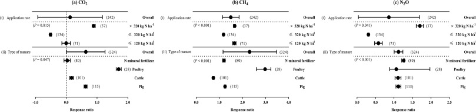

1. [Download : Download high-res image (274KB)](https://ars.els-cdn.com/content/image/1-s2.0-S0959652620340646-gr1_lrg.jpg)
2. [Download : Download full-size image](https://ars.els-cdn.com/content/image/1-s2.0-S0959652620340646-gr1.jpg)

Fig. 1. Impact of (i) animal manure and mineral fertilizer application rate (kg N ha<sup>−1</sup>) and (ii) manure type on (a) CO<sub>2</sub>, (b) CH<sub>4</sub> and (c) N<sub>2</sub>O emissions from agricultural soils. Symbols represent mean effect sizes with 95% confidence intervals. Sample sizes are presented in parentheses and the *P* values are shown in the panel.

Animal manure contains nitrogen (N), phosphorus (P), and other micronutrients that plants need to grow. Farmers can often save money by properly using manure as a fertilizer (Cavalli et al., 2017). On the other hand, the application of animal manure has been a big concern worldwide because manure contributes up to 37% of global GHGs emissions (Vac et al., 2013).

The CH<sub>4</sub> emission from croplands mostly due to anaerobic decomposition of organic matter (Praeg et al., 2016). The application of poultry manure significantly enhanced CH<sub>4</sub> emissions from croplands. This might be because of manure application increase soil microbial biomass and also activities. Therefore, manure application provides more oxidizable C content to the methanotrophs under oxygen limiting conditions, which would increase CH<sub>4</sub> emissions (Pathak, 2015).

Poultry manure also significantly increases N<sub>2</sub>O emission from croplands mainly due to their easily decomposable SOC relative to other manures (Zhou et al., 2017b). One main reason for high N<sub>2</sub>O emission from agricultural soils may be due to high rates of net N mineralization of the poultry manure (Akiyama et al., 2004), which possibly increased nitrification as well as denitrification rates and, subsequently, N<sub>2</sub>O production (Hayakawa et al., 2009).

### 3.2. Water filled pore space (WFPS) and soil pH

Soil pH and WFPS have been recognized as important factors of GHGs emissions (Butterbach-Bahl et al., 2013). Fig. 2 shows the effect sizes of WFPS and soil pH on GHGs emissions from agricultural soils after manure application. From the total, 260 and 408 observations were chosen for WFPS and soil pH, respectively. WFPS was classified as < 30% (n = 53), 30–60% (n = 144) and >60% (n = 63), on the other hand, soil pH was also categorized into three classes like ≤ 6.5 (n = 189), 6.6–7.3(n = 118) and >7.3 (n = 101).

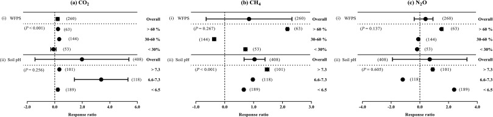

1. [Download : Download high-res image (267KB)](https://ars.els-cdn.com/content/image/1-s2.0-S0959652620340646-gr2_lrg.jpg)
2. [Download : Download full-size image](https://ars.els-cdn.com/content/image/1-s2.0-S0959652620340646-gr2.jpg)

Fig. 2. Effect of (i) WFPS (%) and (ii) soil pH on (a) CO<sub>2</sub>, (b) CH<sub>4</sub> and (c) N<sub>2</sub>O emissions from agricultural soils. Symbols represent mean effect sizes with 95% confidence intervals. Sample sizes are presented in parentheses and the *P* values are shown in the panel.

The emission of CO<sub>2</sub> increased at < 50% WFPS indicating the microbial processes like mineralization were less affected by low moisture content. At > 70% WFPS values, soil CO<sub>2</sub> emissions were significantly inhibited by lack of available oxygen (Franco-Luesma et al., 2020), making soil conditions that promote denitrification (Rowlings et al., 2010).

Several factors are influencing CH<sub>4</sub> emissions in higher WFPSs. Soil conditions that support methanotrophic rather than a methanogenic activity which was favored by low temperature and the high percentage of WFPS (>60%) (García-Marco et al., 2014). Another study found that in the anaerobic environmental conditions, a higher amount of SOM would also contribute to the low CH<sub>4</sub> absorption (Sakabe et al., 2015).

Maximum N<sub>2</sub>O emissions with increasing the WFPS were frequently reported from different research studies (Ruser et al., 2001). A higher amount of water content significantly improved the denitrification process in soil and maximum activity was observed at a WFPS 70% (Ruser et al., 2006). Another study reported the soil with 90% WFPS had the maximum N<sub>2</sub>O emissions. These results show that emissions of N<sub>2</sub>O at higher WFPSs were significantly influenced by SOC contents. The greater specific substrate may have preferred the anoxic microsites formation, which is well-known to enhance N<sub>2</sub>O emissions (Flessa and Beese, 2000).

Consequently, in acid soils, the application of manure could significantly promote N<sub>2</sub>O than N<sub>2</sub> by the denitrification process and consequently enhance N<sub>2</sub>O emissions. Another research found that nitrification as well as denitrification processes are mainly affected by soil pH and result in N<sub>2</sub>O emissions. Normally, autotrophic nitrifiers prefer neutral and/or slightly alkaline conditions for oxidizing NH<sub>4</sub><sup>+</sup> to NO<sub>3</sub><sup>−</sup>, and consequently, the nitrification process is frequently low in acidic soils (Chen et al., 2013).

### 3.3. Soil texture

Effect sizes of soil texture on CO<sub>2</sub>, CH<sub>4</sub> and N<sub>2</sub>O emissions after manure application are shown in Fig. 3. According to our meta-analysis dataset, all soils were classified into different textural classes e.g. clay, clay loam, loam, sandy loam, sandy, sandy clay loam, silt loam, slit clay and silty clay loam.

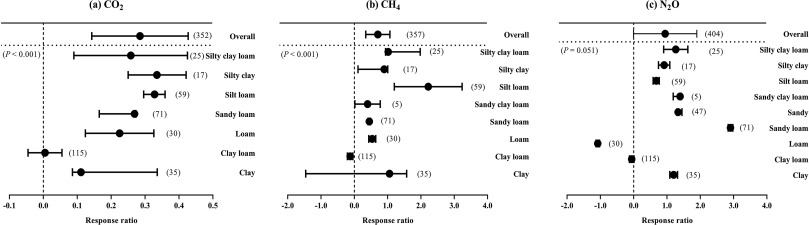

1. [Download : Download high-res image (298KB)](https://ars.els-cdn.com/content/image/1-s2.0-S0959652620340646-gr3_lrg.jpg)
2. [Download : Download full-size image](https://ars.els-cdn.com/content/image/1-s2.0-S0959652620340646-gr3.jpg)

Fig. 3. (a) CO<sub>2</sub>, (b) CH<sub>4</sub> and (c) N<sub>2</sub>O emissions from agricultural soils affected by soil textural class. Symbols represent mean effect sizes with 95% confidence intervals. Sample sizes are presented in parentheses and the *P* values are shown in the panel.

The terrestrial environment serves as a source and sinks for GHGs emissions and soil attributes, in particular, the soil textural classes play a critical role in GHGs emissions (Oertel et al., 2016). Maximum emissions of CO<sub>2</sub> were observed in fine-textured soils compared to coarse-textured soils (Dilustro et al., 2005) which were similar to our results. The mineralization process depends on the bio-availability of organic matter contents. Soils with high clay contents significantly decreased CO<sub>2</sub> emissions because the high capacity of the clay fraction decreased mineralization process (Jäger et al., 2011).

Soil texture significantly controls the emissions of N<sub>2</sub>O through moderating the soil oxygen availability because soil texture has an important impact on the size as well as the distribution of soil pores (Corre et al., 1999). In coarse-textured soils, the nitrification process is the main factor of N<sub>2</sub>O emissions (Zhou et al., 2014). Moreover, manure application to agricultural soils provides a sufficient amount of C substrate that can stimulate the denitrification process and consequently enhance N<sub>2</sub>O emissions after manure application.

### 3.4. Crop duration and type

The crop species and study duration also played an important role in the differences in GHGs emissions (Huang et al., 2018). Different crop species like barley, grassland, maize, rice, soybean, sweet corn, wheat, and the fallow period between crops were chosen for meta-analysis, while, the study duration was categorized as ≤ 320 days, 321–725 days, > 725 days (Fig. 4). In this meta-analysis, the overall effect sizes of crop duration and crop type on CO<sub>2</sub>, CH<sub>4</sub> and N<sub>2</sub>O emissions were $lnRR¯$ = 0.517, 95% CI = 0.226–0.807 and $lnRR¯$ = 1.138, 95% CI = -0.445–3.00, $lnRR¯$ = 0.876, 95% CI = -0.141–1.893 and $lnRR¯$ = 0.919, 95% CI = 0.336–1.502 and $lnRR¯$ = 0.645, 95% CI = -0.271–1.561 and $lnRR¯$ = 1.097, 95% CI = -0.547–2.741, respectively (Table S2).

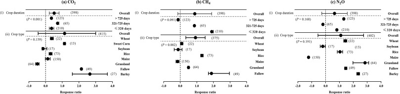

1. [Download : Download high-res image (326KB)](https://ars.els-cdn.com/content/image/1-s2.0-S0959652620340646-gr4_lrg.jpg)
2. [Download : Download full-size image](https://ars.els-cdn.com/content/image/1-s2.0-S0959652620340646-gr4.jpg)

Fig. 4. Influence of (i) crop duration (days) and (ii) crop type on (a) CO<sub>2</sub>, (b) CH<sub>4</sub> and (c) N<sub>2</sub>O emissions from agricultural soils. Symbols represent mean effect sizes with 95% confidence intervals. Sample sizes are presented in parentheses and the *P* values are shown in the panel.

The CO<sub>2</sub> emission was produced through microbial respiration after manure application in the agricultural soils (Li et al., 2016). The effects of the heterotrophic microbial community on SOM decomposition significantly increase CO<sub>2</sub> emissions (Bore et al., 2017). Manure application to the cereal crops is capable of stimulating the organic C pool and, in turn, increases CO<sub>2</sub> emissions (Triberti et al., 2008). The decomposition of SOM significantly increased the C mineralization process and consequently increased CO<sub>2</sub> emissions from croplands (Hossain et al., 2017). Terhoeven-Urselmans et al. (2009) studied and assessed that the C mineralization process significantly increased CO<sub>2</sub> emissions from barley crop after manure application.

The maximum concentration of CH<sub>4</sub> was observed in the fallow and rice crop (Fig. 4b (ii)). Rice paddies are considered among the main sources of man-caused CH<sub>4</sub> emission, contributing up to 6%–20% of the total anthropogenic CH<sub>4</sub> release to the atmosphere (Wang et al., 2017). Wu et al. (2019) also studied and found that rice paddies are significant source of CH<sub>4</sub> emissions. The CH<sub>4</sub> in rice fields is emitted through microbes that respire CO<sub>2</sub>, similar humans respire oxygen. The CH<sub>4</sub> emissions from rice paddies depend on the availability of SOC content and anaerobic conditions (Tariq et al., 2017). Continuous flooding in rice paddies significantly affects the microbial activities in the terrestrial environment (Gebremichael et al., 2017) and increases anaerobic conditions. This process significantly affects the decomposition rate of SOM and ultimately alters the CH<sub>4</sub> emissions. Different researchers also studied and explained that CH<sub>4</sub> emission produced as a result of decomposition of SOM by microbial activates in the absence of oxygen (Conrad, 2009). Under anaerobic conditions, flooded rice paddies are considered one of the most important anthropogenic sources of CH<sub>4</sub> emissions (Hurkuck et al., 2012).

In this meta-analysis, grasslands have been found as a significant source of N<sub>2</sub>O emissions (Fig. 4c (ii)). According to Rafique et al. (2011) research study that approximately 28% of global N<sub>2</sub>O was emitted from grasslands. Van Beek et al. (2010) also found similar findings. Maize crop didn’t show any significant positive effects on all three GHGs emissions while it showed significantly negative effects on N<sub>2</sub>O emissions (Fig. 4c (ii)). Microbial nitrification, nitrifier-denitrification (Xu et al., 2017), respiration, and denitrification are the most important processes affecting the N<sub>2</sub>O emission from the terrestrial environment (Case et al., 2015). Intensively managed grasslands are considered the main source of N<sub>2</sub>O emissions contributing for almost 10% of the global N<sub>2</sub>O emissions (He et al., 2020) and this is mainly attributed to higher manure application as well as animal excreta deposition on grassland surface (Dangal et al., 2019). Application of manure in grassland influences soil biochemical conditions and increases microbial activities which significantly affects the nitrification as well as denitrification process and ultimately changes N<sub>2</sub>O emissions (Schirmann et al., 2020). The GHGs emissions are strongly affected by the amount as well as properties of manure added to the crops.

### 3.5. Climate zone

Fig. 5 shows the effect sizes of climate zones on CO<sub>2</sub>, CH<sub>4,</sub> and N<sub>2</sub>O emissions. Climate zones were divided into warm temperate (n = 134), cool temperate (n = 132), tropical (n = 29), sub-tropical (n = 131) and semi-arid region (n = 4). The overall effect sizes of climate zones were ($lnRR¯$ = 0.345, 95% CI = 0.218–0.471), ($lnRR¯$ = 1.65, 95% CI = -0.302–3.602) and ($lnRR¯$ = 0.506, 95% CI = -0.273–1.285) for CO<sub>2</sub>, CH<sub>4</sub> and N<sub>2</sub>O emissions, respectively (Table S2).

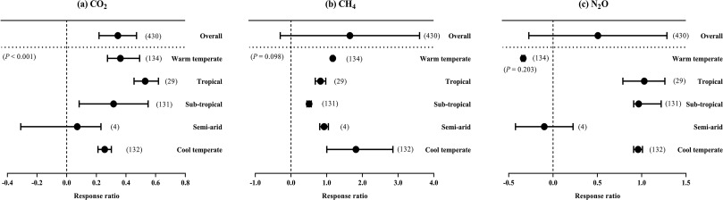

1. [Download : Download high-res image (252KB)](https://ars.els-cdn.com/content/image/1-s2.0-S0959652620340646-gr5_lrg.jpg)
2. [Download : Download full-size image](https://ars.els-cdn.com/content/image/1-s2.0-S0959652620340646-gr5.jpg)

Fig. 5. Effect of climate zone on (a) CO<sub>2</sub>, (b) CH<sub>4</sub> and (c) N<sub>2</sub>O emissions from agricultural soils. Symbols represent mean effect sizes with 95% confidence intervals. Sample sizes are presented in parentheses and the *P* values are shown in the panel.

Agricultural soils contain large concentrations of organic C, reaching approximately 1500 Pg (Pg) (at 1 m depth) (Paustian et al., 2016) and tropical environment provides favorable conditions to microbial communities for the decomposition of organic C, ultimately increase the CO<sub>2</sub> emissions. Globally, the average temperature is expected to rise (1.5–3.9 °C) near the end of 21st century (IPCC, 2014), so, tropical soils could cause roughly a 9% increase in CO<sub>2</sub> emissions this century (Nottingham et al., 2019).

### 3.6. Effect of manure application on GWP

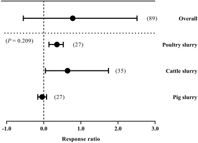

1. [Download : Download high-res image (110KB)](https://ars.els-cdn.com/content/image/1-s2.0-S0959652620340646-gr6_lrg.jpg)
2. [Download : Download full-size image](https://ars.els-cdn.com/content/image/1-s2.0-S0959652620340646-gr6.jpg)

Fig. 6. Effect of manure application on the global warming potential (GWP) of greenhouse gas (GHG) emissions. Symbols represent mean effect sizes with 95% confidence intervals. Sample sizes are presented in parentheses and the *P* values are shown in the panel.

## 4. Limitations and concluding remarks

In this meta-analysis, most of the experiments had been studied in China, Europe and North America. There remains a lack of experimental studies in other continents, like South America, South-East Asia, Africa and Australia. Therefore, long-term experimental research studies are needed with proper manure application rate in these regions to estimate the GHGs emissions. Several research studies had measured GHGs emissions using different animal manures but did not report the summary of statistics that are required for meta-analysis. So, we urge that research scientists must report the proper manure type, complete soil attributes like soil pH, bulk density, soil texture, WFPS, air temperature, proper climate zone, and rainfall, flux type and unit, number of observations and control treatment in their future research studies. This will greatly assist in future meta-analyses which can hopefully provide far greater insights into the range and variability of GHGs emissions than any individual study.

## Declaration of competing interest

The authors declare that they have no known competing financial interests or personal relationships that could have appeared to influence the work reported in this paper.

## Acknowledgments

Awais Shakoor would like to express his gratitude for the grant provided by the University of Lleida, Spain. The authors would like to appreciate the valuable comments from the editors and anonymous reviewers to improve the quality of this study.

## Appendix A. Supplementary data

The following is the Supplementary data to this article:[Download : Download zip file (72KB)](https://ars.els-cdn.com/content/image/1-s2.0-S0959652620340646-mmc1.zip)

Multimedia component 1.

## References

**Abagandura et al., 2019**

G.O. Abagandura, R. Chintala, S.S. Sandhu, S. Kumar, T.E. Schumacher**Effects of biochar and manure applications on soil carbon dioxide, methane, and nitrous oxide fluxes from two different soils**

J. Environ. Qual. (2019), 10.2134/jeq2018.10.0374

0, 0

Google Scholar

**Ahn et al., 2010**

H.K. Ahn, M.C. Smith, S.L. Kondrad, J.W. White**Evaluation of biogas production potential by dry anaerobic digestion of switchgrass-animal manure mixtures**

Appl. Biochem. Biotechnol., 160 (2010), pp. 965-975, 10.1007/s12010-009-8624-x

[CrossRef](https://doi.org/10.1007/s12010-009-8624-x)[View Record in Scopus](https://www.scopus.com/inward/record.url?eid=2-s2.0-77949295611&partnerID=10&rel=R3.0.0)Google Scholar

**Akiyama et al., 2004**

H. Akiyama, I.P. McTaggart, B.C. Ball, A. Scott**N 2O, NO, and NH 3 emissions from soil after the application of organic fertilizers, urea and water**

Water Air Soil Pollut., 156 (2004), pp. 113-129, 10.1023/B:WATE.0000036800.20599.46

[CrossRef](https://doi.org/10.1023/B:WATE.0000036800.20599.46)[View Record in Scopus](https://www.scopus.com/inward/record.url?eid=2-s2.0-4043110556&partnerID=10&rel=R3.0.0)Google Scholar

**Alluvione et al., 2009**

F. Alluvione, A.D. Halvorson, S.J. Del Grosso**Nitrogen, tillage, and crop rotation effects on carbon dioxide and methane fluxes from irrigated cropping systems**

J. Environ. Qual., 38 (2009), pp. 2023-2033, 10.2134/jeq2008.0517

[CrossRef](https://doi.org/10.2134/jeq2008.0517)[View Record in Scopus](https://www.scopus.com/inward/record.url?eid=2-s2.0-69749111478&partnerID=10&rel=R3.0.0)Google Scholar

**Asgedom et al., 2014**

H. Asgedom, M. Tenuta, D.N. Flaten, X. Gao, E. Kebreab**Nitrous oxide emissions from a clay soil receiving granular urea formulations and dairy manure**

Agron. J., 106 (2014), pp. 732-744, 10.2134/agronj2013.0096

[CrossRef](https://doi.org/10.2134/agronj2013.0096)[View Record in Scopus](https://www.scopus.com/inward/record.url?eid=2-s2.0-84895766303&partnerID=10&rel=R3.0.0)Google Scholar

**Bakken et al., 2012**

L.R. Bakken, L. Bergaust, B. Liu, Å. Frostegård**Regulation of denitrification at the cellular level: a clue to the understanding of N2O emissions from soils**

Philos. Trans. R. Soc. B Biol. Sci., 367 (2012), pp. 1226-1234, 10.1098/rstb.2011.0321

[CrossRef](https://doi.org/10.1098/rstb.2011.0321)[View Record in Scopus](https://www.scopus.com/inward/record.url?eid=2-s2.0-84859055058&partnerID=10&rel=R3.0.0)Google Scholar

**Ball, 2013**

B.C. Ball**Soil structure and greenhouse gas emissions: a synthesis of 20 years of experimentation**

Eur. J. Soil Sci., 64 (2013), pp. 357-373, 10.1111/ejss.12013

[CrossRef](https://doi.org/10.1111/ejss.12013)[View Record in Scopus](https://www.scopus.com/inward/record.url?eid=2-s2.0-84879410888&partnerID=10&rel=R3.0.0)[Google Scholar](https://scholar.google.com/scholar_lookup?title=Soil%20structure%20and%20greenhouse%20gas%20emissions%3A%20a%20synthesis%20of%2020%20years%20of%20experimentation&publication_year=2013&author=B.C.%20Ball)

**Ball et al., 2004**

B.C. Ball, B.C. Ball, I.P. McTaggart, A. Scott**Mitigation of greenhouse gas emissions from soil under silage production by use of organic manures or slow-release fertilizer**

Soil Use Manag., 20 (2004), pp. 287-295, 10.1079/sum2004257

[View Record in Scopus](https://www.scopus.com/inward/record.url?eid=2-s2.0-7944228681&partnerID=10&rel=R3.0.0)Google Scholar

**Barnard et al., 2005**

R. Barnard, P.W. Leadley, B.A. Hungate**Global change, nitrification, and denitrification: a review**

Global Biogeochem. Cycles, 19 (2005), pp. 1-13, 10.1029/2004GB002282

[View Record in Scopus](https://www.scopus.com/inward/record.url?eid=2-s2.0-20444374146&partnerID=10&rel=R3.0.0)Google Scholar

**Bertora et al., 2008**

C. Bertora, F. Alluvione, L. Zavattaro, J.W. van Groenigen, G. Velthof, C. Grignani**Pig slurry treatment modifies slurry composition, N2O, and CO2 emissions after soil incorporation**

Soil Biol. Biochem., 40 (2008), pp. 1999-2006, 10.1016/j.soilbio.2008.03.021

[Article](https://www.sciencedirect.com/science/article/pii/S0038071708001107)[Download PDF](https://www.sciencedirect.com/science/article/pii/S0038071708001107/pdfft?md5=ab926aedde628e8d155a34bb84917a35&pid=1-s2.0-S0038071708001107-main.pdf)[View Record in Scopus](https://www.scopus.com/inward/record.url?eid=2-s2.0-45549084416&partnerID=10&rel=R3.0.0)Google Scholar

**Bore et al., 2017**

E. Bore, C. Apostel, S. Halicki, Y. Kuzyakov, M.A. Dippold**Soil microorganisms can overcome respiration inhibition by coupling intra- and extracellular metabolism: 13C metabolic tracing reveals the mechanisms**

ISME J. (2017), pp. 1-11, 10.1038/ismej.2017.3

[View Record in Scopus](https://www.scopus.com/inward/record.url?eid=2-s2.0-85086719972&partnerID=10&rel=R3.0.0)Google Scholar

**Bourdin et al., 2014**

F. Bourdin, R. Sakrabani, M.G. Kibblewhite, G.J. Lanigan**Effect of slurry dry matter content, application technique and timing on emissions of ammonia and greenhouse gas from cattle slurry applied to grassland soils in Ireland**

Agric. Ecosyst. Environ., 188 (2014), pp. 122-133, 10.1016/j.agee.2014.02.025

[Article](https://www.sciencedirect.com/science/article/pii/S0167880914001066)[Download PDF](https://www.sciencedirect.com/science/article/pii/S0167880914001066/pdfft?md5=3976841e1478bf1776071c6b7505548b&pid=1-s2.0-S0167880914001066-main.pdf)[View Record in Scopus](https://www.scopus.com/inward/record.url?eid=2-s2.0-84896506144&partnerID=10&rel=R3.0.0)Google Scholar

**Brennan et al., 2015**

R.B. Brennan, M.G. Healy, O. Fenton, G.J. Lanigan**The effect of chemical amendments used for phosphorus abatement on greenhouse gas and ammonia emissions from dairy cattle slurry: synergies and pollution swapping**

PloS One, 10 (2015), pp. 1-20, 10.1371/journal.pone.0111965

[CrossRef](https://doi.org/10.2979/filmhistory.27.2.1)Google Scholar

**Butterbach-Bahl et al., 2013**

K. Butterbach-Bahl, E.M. Baggs, M. Dannenmann, R. Kiese, S. Zechmeister-Boltenstern**Nitrous oxide emissions from soils: how well do we understand the processes and their controls?**

Philos. Trans. R. Soc. B Biol. Sci., 368 (2013), 10.1098/rstb.2013.0122

[Google Scholar](https://scholar.google.com/scholar?q=Nitrous%20oxide%20emissions%20from%20soils:%20how%20well%20do%20we%20understand%20the%20processes%20and%20their%20controls)

**Case et al., 2015**

S.D.C. Case, N.P. McNamara, D.S. Reay, A.W. Stott, H.K. Grant, J. Whitaker**Biochar suppresses N2O emissions while maintaining N availability in a sandy loam soil**

Soil Biol. Biochem., 81 (2015), pp. 178-185, 10.1016/j.soilbio.2014.11.012

[Article](https://www.sciencedirect.com/science/article/pii/S0038071714003988)[Download PDF](https://www.sciencedirect.com/science/article/pii/S0038071714003988/pdfft?md5=07276bc298da2d461be10ce159e4daca&pid=1-s2.0-S0038071714003988-main.pdf)[View Record in Scopus](https://www.scopus.com/inward/record.url?eid=2-s2.0-84949114923&partnerID=10&rel=R3.0.0)Google Scholar

**Cayuela et al., 2017**

M.L. Cayuela, E. Aguilera, A. Sanz-Cobena, D.C. Adams, D. Abalos, L. Barton, R. Ryals, W.L. Silver, M.A. Alfaro, V.A. Pappa, P. Smith, J. Garnier, G. Billen, L. Bouwman, A. Bondeau, L. Lassaletta**Direct nitrous oxide emissions in Mediterranean climate cropping systems: emission factors based on a meta-analysis of available measurement data**

Agric. Ecosyst. Environ., 238 (2017), pp. 25-35, 10.1016/j.agee.2016.10.006

[Article](https://www.sciencedirect.com/science/article/pii/S0167880916304984)[Download PDF](https://www.sciencedirect.com/science/article/pii/S0167880916304984/pdfft?md5=1c3021206ffedfd65d854502ca671c22&pid=1-s2.0-S0167880916304984-main.pdf)[View Record in Scopus](https://www.scopus.com/inward/record.url?eid=2-s2.0-84992052804&partnerID=10&rel=R3.0.0)Google Scholar

**Chadwick et al., 2000**

D.R. Chadwick, B.F. Pain, S.K.E. Brookman**Nitrous oxide and methane emissions following application of animal manures to grassland**

J. Environ. Qual., 29 (2000), pp. 277-287, 10.2134/jeq2000.00472425002900010035x

[CrossRef](https://doi.org/10.2134/jeq2000.00472425002900010035x)[View Record in Scopus](https://www.scopus.com/inward/record.url?eid=2-s2.0-0033984124&partnerID=10&rel=R3.0.0)Google Scholar

**Chantigny et al., 2016**

M.H. Chantigny, P. Rochette, D.A. Angers, C. Goyer, L.D. Brin, N. Bertrand**Nongrowing season N2O and CO2 emissions — temporal dynamics and influence of soil texture and fall-applied manure**

Can. J. Soil Sci., 97 (2016), pp. 452-464, 10.1139/cjss-2016-0110

[View Record in Scopus](https://www.scopus.com/inward/record.url?eid=2-s2.0-85028703456&partnerID=10&rel=R3.0.0)[Google Scholar](https://scholar.google.com/scholar?q=Nongrowing%20season%20N2O%20and%20CO2%20emissions%20%20temporal%20dynamics%20and%20influence%20of%20soil%20texture%20and%20fall-applied%20manure)

**Charles et al., 2017**

A. Charles, P. Rochette, J.K. Whalen, D.A. Angers, M.H. Chantigny, N. Bertrand**Global nitrous oxide emission factors from agricultural soils after addition of organic amendments: a meta-analysis**

Agric. Ecosyst. Environ., 236 (2017), pp. 88-98, 10.1016/j.agee.2016.11.021

[Article](https://www.sciencedirect.com/science/article/pii/S0167880916305795)[Download PDF](https://www.sciencedirect.com/science/article/pii/S0167880916305795/pdfft?md5=893af2c2165e4f049044310d309693f9&pid=1-s2.0-S0167880916305795-main.pdf)[View Record in Scopus](https://www.scopus.com/inward/record.url?eid=2-s2.0-84998655163&partnerID=10&rel=R3.0.0)Google Scholar

**Chen et al., 2013**

H. Chen, X. Li, F. Hu, W. Shi**Soil nitrous oxide emissions following crop residue addition: a meta-analysis**

Global Change Biol., 19 (2013), pp. 2956-2964, 10.1111/gcb.12274

[CrossRef](https://doi.org/10.1111/gcb.12274)[View Record in Scopus](https://www.scopus.com/inward/record.url?eid=2-s2.0-84883553756&partnerID=10&rel=R3.0.0)Google Scholar

**Ciais et al., 2013**

P. Ciais, C. Sabine, G. Bala, L. Bopp, V. Brovkin, J. Canadell, a Chhabra, R. DeFries, J. Galloway, M. Heimann, C. Jones, C. Le Quéré, R.B. Myneni, S. Piao, P. Thornton**Carbon and other biogeochemical cycles, climate change 2013 - the physical science basis**

https://doi.org/10.1017/CBO9781107415324.015 (2013)

Google Scholar

**Cole et al., 1997**

C.V. Cole, J. Duxbury, J. Freney, O. Heinemeyer, K. Minami, A. Mosier, K. Paustian, N. Rosenberg, N. Sampson, D. Sauerbeck, Q. Zhao**Global estimates of potential mitigation of greenhouse gas emissions by agriculture**

Nutrient Cycl. Agroecosyst., 49 (1997), pp. 221-228, 10.1023/A:1009731711346

[View Record in Scopus](https://www.scopus.com/inward/record.url?eid=2-s2.0-0000051059&partnerID=10&rel=R3.0.0)Google Scholar

**Collins et al., 2011**

H.P. Collins, A.K. Alva, J.D. Streubel, S.F. Fransen, C. Frear, S. Chen, C. Kruger, D. Granatstein**Greenhouse gas emissions from an irrigated silt loam soil amended with anaerobically digested dairy manure**

Soil Sci. Soc. Am. J., 75 (2011), pp. 2206-2216, 10.2136/sssaj2010.0360

[CrossRef](https://doi.org/10.2136/sssaj2010.0360)[View Record in Scopus](https://www.scopus.com/inward/record.url?eid=2-s2.0-83055164412&partnerID=10&rel=R3.0.0)Google Scholar

**Conrad, 2009**

R. Conrad**The global methane cycle: recent advances in understanding the microbial processes involved**

Environ. Microbiol. Rep., 1 (2009), pp. 285-292, 10.1111/j.1758-2229.2009.00038.x

[CrossRef](https://doi.org/10.1111/j.1758-2229.2009.00038.x)[View Record in Scopus](https://www.scopus.com/inward/record.url?eid=2-s2.0-77950649410&partnerID=10&rel=R3.0.0)[Google Scholar](https://scholar.google.com/scholar_lookup?title=The%20global%20methane%20cycle%3A%20recent%20advances%20in%20understanding%20the%20microbial%20processes%20involved&publication_year=2009&author=R.%20Conrad)

**Corre et al., 1999**

M.D. Corre, D.J. Pennock, C. Van Kessel, D.K. Elliott**Estimation of annual nitrous oxide emissions from a transitional grassland-forest region in Saskatchewan, Canada**

Biogeochemistry, 44 (1999), pp. 29-49, 10.1023/A:1006025907180

[View Record in Scopus](https://www.scopus.com/inward/record.url?eid=2-s2.0-0033065862&partnerID=10&rel=R3.0.0)Google Scholar

**Cote and Ndayegamiye, 1989**

D. Cote, A. Ndayegamiye**Effect of long-term pig SLTJRRY and solid cattle manure appli. Cation on soil chemical and biological properties**

Can. J. Soil Sci., 69 (1989), pp. 39-47

Google Scholar

**Dambreville et al., 2008**

C. Dambreville, T. Morvan, J.C. Germon**N2O emission in maize-crops fertilized with pig slurry, matured pig manure or ammonium nitrate in Brittany**

Agric. Ecosyst. Environ., 123 (2008), pp. 201-210, 10.1016/j.agee.2007.06.001

[Article](https://www.sciencedirect.com/science/article/pii/S0167880907001715)[Download PDF](https://www.sciencedirect.com/science/article/pii/S0167880907001715/pdfft?md5=f44d7f77c92b693cf23e24afa6a8eff9&pid=1-s2.0-S0167880907001715-main.pdf)[View Record in Scopus](https://www.scopus.com/inward/record.url?eid=2-s2.0-35348937230&partnerID=10&rel=R3.0.0)Google Scholar

**Dangal et al., 2019**

S.R.S. Dangal, H. Tian, R. Xu, J. Chang, J.G. Canadell, P. Ciais, S. Pan, J. Yang, B. Zhang**Global nitrous oxide emissions from pasturelands and rangelands: magnitude, spatiotemporal patterns, and attribution**

Global Biogeochem. Cycles, 33 (2019), pp. 200-222, 10.1029/2018GB006091

[CrossRef](https://doi.org/10.1029/2018gb006091)[View Record in Scopus](https://www.scopus.com/inward/record.url?eid=2-s2.0-85061922592&partnerID=10&rel=R3.0.0)Google Scholar

**Das and Adhya, 2014**

S. Das, T.K. Adhya**Effect of combine application of organic manure and inorganic fertilizer on methane and nitrous oxide emissions from a tropical flooded soil planted to rice**

Geoderma, 213 (2014), pp. 185-192, 10.1016/j.geoderma.2013.08.011

[Article](https://www.sciencedirect.com/science/article/pii/S0016706113002930)[Download PDF](https://www.sciencedirect.com/science/article/pii/S0016706113002930/pdfft?md5=5551770d5afd23725dd4e045dc0ecde5&pid=1-s2.0-S0016706113002930-main.pdf)[View Record in Scopus](https://www.scopus.com/inward/record.url?eid=2-s2.0-84883796847&partnerID=10&rel=R3.0.0)Google Scholar

**De Rosa et al., 2018**

D. De Rosa, D.W. Rowlings, J. Biala, C. Scheer, B. Basso, P.R. Grace**N2O and CO2 emissions following repeated application of organic and mineral N fertiliser from a vegetable crop rotation**

Sci. Total Environ., 637–638 (2018), pp. 813-824, 10.1016/j.scitotenv.2018.05.046

[Article](https://www.sciencedirect.com/science/article/pii/S0048969718316802)[Download PDF](https://www.sciencedirect.com/science/article/pii/S0048969718316802/pdfft?md5=230152ae356ea7171e42a25acba37d56&pid=1-s2.0-S0048969718316802-main.pdf)[View Record in Scopus](https://www.scopus.com/inward/record.url?eid=2-s2.0-85047075369&partnerID=10&rel=R3.0.0)Google Scholar

**Dendooven et al., 1998**

L. Dendooven, E. Bonhomme, R. Merckx, K. Vlassak**N dynamics and sources of N2O production following pig slurry application to a loamy soil**

Biol. Fertil. Soils, 26 (1998), pp. 224-228, 10.1007/s003740050371

[View Record in Scopus](https://www.scopus.com/inward/record.url?eid=2-s2.0-0031932067&partnerID=10&rel=R3.0.0)Google Scholar

**Dilustro et al., 2005**

J.J. Dilustro, B. Collins, L. Duncan, C. Crawford**Moisture and soil texture effects on soil CO2 efflux components in southeastern mixed pine forests**

For. Ecol. Manage., 204 (2005), pp. 87-97, 10.1016/j.foreco.2004.09.001

[Article](https://www.sciencedirect.com/science/article/pii/S0378112704006498)[Download PDF](https://www.sciencedirect.com/science/article/pii/S0378112704006498/pdfft?md5=6c481f9bced5fd132791d0b88ac98438&pid=1-s2.0-S0378112704006498-main.pdf)[View Record in Scopus](https://www.scopus.com/inward/record.url?eid=2-s2.0-10944250938&partnerID=10&rel=R3.0.0)Google Scholar

**Dinuccio et al., 2011**

E. Dinuccio, W. Berg, P. Balsari**Effects of mechanical separation on GHG and ammonia emissions from cattle slurry under winter conditions**

Anim. Feed Sci. Technol., 166–167 (2011), pp. 532-538, 10.1016/j.anifeedsci.2011.04.037

[Article](https://www.sciencedirect.com/science/article/pii/S0377840111001568)[Download PDF](https://www.sciencedirect.com/science/article/pii/S0377840111001568/pdfft?md5=c2b05888a9cc1c720db2f669b483278f&pid=1-s2.0-S0377840111001568-main.pdf)[View Record in Scopus](https://www.scopus.com/inward/record.url?eid=2-s2.0-79958765539&partnerID=10&rel=R3.0.0)Google Scholar

**Drigo et al., 2008**

B. Drigo, G.A. Kowalchuk, J.A. Van Veen**Climate change goes underground: effects of elevated atmospheric CO 2 on microbial community structure and activities in the rhizosphere**

Biol. Fertil. Soils, 44 (2008), pp. 667-679, 10.1007/s00374-008-0277-3

[CrossRef](https://doi.org/10.1007/s00374-008-0277-3)[View Record in Scopus](https://www.scopus.com/inward/record.url?eid=2-s2.0-43349094712&partnerID=10&rel=R3.0.0)Google Scholar

**Dutaur and Verchot, 2007**

L. Dutaur, L.V. Verchot**A global inventory of the soil CH4 sink**

Global Biogeochem. Cycles, 21 (2007), pp. 1-9, 10.1029/2006GB002734

[Google Scholar](https://scholar.google.com/scholar_lookup?title=A%C2%A0global%20inventory%20of%20the%20soil%20CH4%20sink&publication_year=2007&author=L.%20Dutaur&author=L.V.%20Verchot)

**Fangueiro et al., 2008**

D. Fangueiro, M. Senbayran, H. Trindade, D. Chadwick**Cattle slurry treatment by screw press separation and chemically enhanced settling: effect on greenhouse gas emissions after land spreading and grass yield**

Bioresour. Technol., 99 (2008), pp. 7132-7142, 10.1016/j.biortech.2007.12.069

[Article](https://www.sciencedirect.com/science/article/pii/S0960852408000035)[Download PDF](https://www.sciencedirect.com/science/article/pii/S0960852408000035/pdfft?md5=2d6fd847478f4fc2e9ae793ab5a90a5e&pid=1-s2.0-S0960852408000035-main.pdf)[View Record in Scopus](https://www.scopus.com/inward/record.url?eid=2-s2.0-44649144604&partnerID=10&rel=R3.0.0)Google Scholar

**FAO, 2014**

FAO**Agriculture , Forestry and Other Land Use Emissions by Sources and Removals by Sinks**

(2014)

[Google Scholar](https://scholar.google.com/scholar_lookup?title=Agriculture%20%2C%20Forestry%20and%20Other%20Land%20Use%20Emissions%20by%20Sources%20and%20Removals%20by%20Sinks&publication_year=2014&author=FAO)

**Flessa and Beese, 2000**

H. Flessa, F. Beese**Laboratory estimates of trace gas emissions following surface application and injection of cattle slurry**

J. Environ. Qual., 29 (2000), pp. 262-268, 10.2134/jeq2000.00472425002900010033x

[CrossRef](https://doi.org/10.2134/jeq2000.00472425002900010033x)[View Record in Scopus](https://www.scopus.com/inward/record.url?eid=2-s2.0-0033984122&partnerID=10&rel=R3.0.0)Google Scholar

**Franco-Luesma et al., 2020**

S. Franco-Luesma, J. Cavero, D. Plaza-Bonilla, C. Cantero-Martínez, J.L. Arrúe, J. Álvaro-Fuentes**Tillage and irrigation system effects on soil carbon dioxide (CO2) and methane (CH4) emissions in a maize monoculture under Mediterranean conditions**

Soil Tillage Res., 196 (2020), p. 104488, 10.1016/j.still.2019.104488

[Article](https://www.sciencedirect.com/science/article/pii/S016719871931044X)[Download PDF](https://www.sciencedirect.com/science/article/pii/S016719871931044X/pdfft?md5=725aa7599b31a44b938efbda7cf85ed1&pid=1-s2.0-S016719871931044X-main.pdf)Google Scholar

**Freeman et al., 1986**

P.R. Freeman, L.V. Hedges, I. Olkin**Statistical methods for meta-analysis**

Biometrics, 42 (1986), p. 454, 10.2307/2531069

[CrossRef](https://doi.org/10.2307/2531069)[View Record in Scopus](https://www.scopus.com/inward/record.url?eid=2-s2.0-85090424951&partnerID=10&rel=R3.0.0)[Google Scholar](https://scholar.google.com/scholar_lookup?title=Statistical%20methods%20for%20meta-analysis&publication_year=1986&author=P.R.%20Freeman&author=L.V.%20Hedges&author=I.%20Olkin)

**Gan et al., 2012**

Y. Gan, C. Liang, W. May, S.S. Malhi, J. Niu, X. Wang**Carbon footprint of spring barley in relation to preceding oilseeds and N fertilization**

Int. J. Life Cycle Assess., 17 (2012), pp. 635-645, 10.1007/s11367-012-0383-1

[CrossRef](https://doi.org/10.1007/s11367-012-0383-1)[View Record in Scopus](https://www.scopus.com/inward/record.url?eid=2-s2.0-84865146372&partnerID=10&rel=R3.0.0)Google Scholar

**Gao et al., 2014**

X. Gao, M. Tenuta, K.E. Buckley, F. Zvomuya, K. Ominski**Greenhouse gas emissions from pig slurry applied to forage legumes on a loamy sand soil in south central Manitoba**

Can. J. Soil Sci., 94 (2014), pp. 149-155, 10.4141/CJSS2013-117

[CrossRef](https://doi.org/10.4141/cjss2013-117)[View Record in Scopus](https://www.scopus.com/inward/record.url?eid=2-s2.0-84899871422&partnerID=10&rel=R3.0.0)Google Scholar

**García-Marco et al., 2014**

S. García-Marco, S.R. Ravella, D. Chadwick, A. Vallejo, A.S. Gregory, L.M. Cárdenas**Ranking factors affecting emissions of GHG from incubated agricultural soils**

Eur. J. Soil Sci., 65 (2014), pp. 573-583, 10.1111/ejss.12143

[CrossRef](https://doi.org/10.1111/ejss.12143)[View Record in Scopus](https://www.scopus.com/inward/record.url?eid=2-s2.0-84903887300&partnerID=10&rel=R3.0.0)Google Scholar

**Gattinger et al., 2012**

A. Gattinger, A. Muller, M. Haeni, C. Skinner, A. Fliessbach, N. Buchmann, P. Mäder, M. Stolze, P. Smith, N.E.H. Scialabba, U. Niggli**Enhanced top soil carbon stocks under organic farming**

Proc. Natl. Acad. Sci. U. S. A, 109 (2012), pp. 18226-18231, 10.1073/pnas.1209429109

[CrossRef](https://doi.org/10.1073/pnas.1209429109)[View Record in Scopus](https://www.scopus.com/inward/record.url?eid=2-s2.0-84868146103&partnerID=10&rel=R3.0.0)Google Scholar

**Gebremichael et al., 2017**

A.W. Gebremichael, B. Osborne, P. Orr**Flooding-related increases in CO2 and N2O emissions from a temperate coastal grassland ecosystem**

Biogeosciences, 14 (2017), pp. 2611-2626, 10.5194/bg-14-2611-2017

[CrossRef](https://doi.org/10.5194/bg-14-2611-2017)[View Record in Scopus](https://www.scopus.com/inward/record.url?eid=2-s2.0-85019899936&partnerID=10&rel=R3.0.0)Google Scholar

**Goldman et al., 2017**

J.A.L. Goldman, M.L. Bender, F.M.M. Morel**The effects of pH and p CO 2 on photosynthesis and respiration in the diatom Thalassiosira weissflogii**

Photosynth. Res., 132 (2017), pp. 83-93, 10.1007/s11120-016-0330-2

[CrossRef](https://doi.org/10.1007/s11120-016-0330-2)[View Record in Scopus](https://www.scopus.com/inward/record.url?eid=2-s2.0-85008474481&partnerID=10&rel=R3.0.0)Google Scholar

**Grave et al., 2015**

R.A. Grave, R.daS. Nicoloso, P.C. Cassol, C. Aita, J.C. Corrêa, M.D. Costa, D.D. Fritz**Short-term carbon dioxide emission under contrasting soil disturbance levels and organic amendments**

Soil Tillage Res., 146 (2015), pp. 184-192, 10.1016/j.still.2014.10.010

[Article](https://www.sciencedirect.com/science/article/pii/S0167198714002190)[Download PDF](https://www.sciencedirect.com/science/article/pii/S0167198714002190/pdfft?md5=fe31baec9cbc5777725acf3738314ee0&pid=1-s2.0-S0167198714002190-main.pdf)[View Record in Scopus](https://www.scopus.com/inward/record.url?eid=2-s2.0-84910019985&partnerID=10&rel=R3.0.0)Google Scholar

**Griffis et al., 2017**

T.J. Griffis, Z. Chen, J.M. Baker, J.D. Wood, D.B. Millet, X. Lee, R.T. Venterea, P.A. Turner**Nitrous oxide emissions are enhanced in a warmer and wetter world**

Proc. Natl. Acad. Sci. U. S. A, 114 (2017), pp. 12081-12085, 10.1073/pnas.1704552114

[CrossRef](https://doi.org/10.1073/pnas.1704552114)[View Record in Scopus](https://www.scopus.com/inward/record.url?eid=2-s2.0-85033794225&partnerID=10&rel=R3.0.0)Google Scholar

**Havlin et al., 2013**

J.L. Havlin, J.D. Beaton, S.L. Tisdale, W.R. Nelson, W.L. Nelson

SOIL FERTILITY and FERTILIZERS, an Introduction to Nutrient Management Title Soil Fertility and Fertilizers, vol. 50 (2013)

**Hayakawa et al., 2009**

A. Hayakawa, H. Akiyama, S. Sudo, K. Yagi**N2O and NO emissions from an Andisol field as influenced by pelleted poultry manure**

Soil Biol. Biochem., 41 (2009), pp. 521-529, 10.1016/j.soilbio.2008.12.011

[Article](https://www.sciencedirect.com/science/article/pii/S0038071708004513)[Download PDF](https://www.sciencedirect.com/science/article/pii/S0038071708004513/pdfft?md5=0d9a7f84afa216399036ad39c5b95cb5&pid=1-s2.0-S0038071708004513-main.pdf)[View Record in Scopus](https://www.scopus.com/inward/record.url?eid=2-s2.0-60249083119&partnerID=10&rel=R3.0.0)Google Scholar

**Haynes and Naidu, 1998**

R.J. Haynes, R. Naidu**Influence of lime, fertilizer and manure applications on soil organic matter**

Nutrient Cycl. Agroecosyst., 51 (1998), pp. 123-137, 10.1023/A:1009738307837

[CrossRef](https://doi.org/10.1023/A:1009738307837)[View Record in Scopus](https://www.scopus.com/inward/record.url?eid=2-s2.0-0031959149&partnerID=10&rel=R3.0.0)[Google Scholar](https://scholar.google.com/scholar_lookup?title=Influence%20of%20lime%2C%20fertilizer%20and%20manure%20applications%20on%20soil%20organic%20matter&publication_year=1998&author=R.J.%20Haynes&author=R.%20Naidu)

**He et al., 2017**

Y. He, X. Zhou, L. Jiang, M. Li, Z. Du, G. Zhou, J. Shao, X. Wang, Z. Xu, S. Hosseini Bai, H. Wallace, C. Xu**Effects of biochar application on soil greenhouse gas fluxes: a meta-analysis**

GCB Bioenergy, 9 (2017), pp. 743-755, 10.1111/gcbb.12376

[CrossRef](https://doi.org/10.1111/gcbb.12376)[View Record in Scopus](https://www.scopus.com/inward/record.url?eid=2-s2.0-84979221644&partnerID=10&rel=R3.0.0)Google Scholar

**He et al., 2020**

W. He, B. Dutta, B.B. Grant, M.H. Chantigny, D. Hunt, S. Bittman, M. Tenuta, D. Worth, A. VanderZaag, R.L. Desjardins, W.N. Smith**Assessing the effects of manure application rate and timing on nitrous oxide emissions from managed grasslands under contrasting climate in Canada**

Sci. Total Environ., 716 (2020), p. 135374, 10.1016/j.scitotenv.2019.135374

[Article](https://www.sciencedirect.com/science/article/pii/S0048969719353665)[Download PDF](https://www.sciencedirect.com/science/article/pii/S0048969719353665/pdfft?md5=e721c3fdcf64b168a113dfe968c81dc5&pid=1-s2.0-S0048969719353665-main.pdf)Google Scholar

**Hedges et al., 1999**

L.V. Hedges, J. Gurevitch, P.S. Curtis**The meta-analysis of response ratios in experimental ecology**

Ecology, 80 (1999), pp. 1150-1156, 10.1890/0012-9658(1999)080[1150:TMAORR]2.0.CO;2

[View Record in Scopus](https://www.scopus.com/inward/record.url?eid=2-s2.0-0033037138&partnerID=10&rel=R3.0.0)[Google Scholar](https://scholar.google.com/scholar_lookup?title=The%20meta-analysis%20of%20response%20ratios%20in%20experimental%20ecology&publication_year=1999&author=L.V.%20Hedges&author=J.%20Gurevitch&author=P.S.%20Curtis)

**Herr et al., 2019**

C. Herr, T. Mannheim, T. Müller, R. Ruser**Effect of cattle slurry application techniques on N 2 O and NH 3 emissions from a loamy soil**

J. Plant Nutr. Soil Sci. (2019), pp. 1-16, 10.1002/jpln.201800376

[CrossRef](https://doi.org/10.1097/01821703-900000000-99973)Google Scholar

**Horn et al., 2003**

M.A. Horn, C. Matthies, K. Küsel, A. Schramm, H.L. Drake**Hydrogenotrophic methanogenesis by moderately acid-tolerant methanogens of a methane-emitting acidic peat**

Appl. Environ. Microbiol., 69 (2003), pp. 74-83, 10.1128/AEM.69.1.74-83.2003

[View Record in Scopus](https://www.scopus.com/inward/record.url?eid=2-s2.0-0037224849&partnerID=10&rel=R3.0.0)Google Scholar

**Hossain et al., 2017**

M.B. Hossain, M.M. Rahman, J.C. Biswas, M.M.U. Miah, S. Akhter, M. Maniruzzaman, A.K. Choudhury, F. Ahmed, M.H.K. Shiragi, N. Kalra**Carbon mineralization and carbon dioxide emission from organic matter added soil under different temperature regimes**

Int. J. Recycl. Org. Waste Agric., 6 (2017), pp. 311-319, 10.1007/s40093-017-0179-1

[CrossRef](https://doi.org/10.1007/s40093-017-0179-1)[View Record in Scopus](https://www.scopus.com/inward/record.url?eid=2-s2.0-85036662860&partnerID=10&rel=R3.0.0)Google Scholar

**Huang et al., 2018**

Y. Huang, W. Ren, L. Wang, D. Hui, J.H. Grove, X. Yang, B. Tao, B. Goff**Greenhouse gas emissions and crop yield in no-tillage systems: a meta-analysis**

Agric. Ecosyst. Environ., 268 (2018), pp. 144-153, 10.1016/j.agee.2018.09.002

[Article](https://www.sciencedirect.com/science/article/pii/S016788091830375X)[Download PDF](https://www.sciencedirect.com/science/article/pii/S016788091830375X/pdfft?md5=d44fa7d91cb10b85620c616a7eb61965&pid=1-s2.0-S016788091830375X-main.pdf)[View Record in Scopus](https://www.scopus.com/inward/record.url?eid=2-s2.0-85053540774&partnerID=10&rel=R3.0.0)Google Scholar

**Hurkuck et al., 2012**

M. Hurkuck, F. Althoff, H.F. Jungkunst, A. Jugold, F. Keppler**Release of methane from aerobic soil: an indication of a novel chemical natural process?**

Chemosphere, 86 (2012), pp. 684-689, 10.1016/j.chemosphere.2011.11.024

[Article](https://www.sciencedirect.com/science/article/pii/S0045653511013166)[Download PDF](https://www.sciencedirect.com/science/article/pii/S0045653511013166/pdfft?md5=e837798b340a0104b069c580c6de0ecc&pid=1-s2.0-S0045653511013166-main.pdf)[View Record in Scopus](https://www.scopus.com/inward/record.url?eid=2-s2.0-84856048711&partnerID=10&rel=R3.0.0)[Google Scholar](https://scholar.google.com/scholar?q=Release%20of%20methane%20from%20aerobic%20soil:%20an%20indication%20of%20a%20novel%20chemical%20natural%20process)

**IPCC, 2006**

IPCC**Guidelines for National Greenhouse Gas Inventories, Volume 4: Agriculture, Forestry and Other Land Use, Chapter 10 Emissions from Livestock and Manure Management 4**

(2006)

Google Scholar

**IPCC, 2013**

IPCC**Climate change 2013: the physical science basis**

Climatic Change, 1535 (2013), 10.1017/CBO9781107415324

2013

[Google Scholar](https://scholar.google.com/scholar_lookup?title=Climate%20change%202013%3A%20the%20physical%20science%20basis&publication_year=2013&author=IPCC)

**IPCC, 2014**

IPCC**Climate change 2014: synthesis report. Contribution of working groups I, II and III to the fifth assessment report of the intergovernmental panel on climate change**

J. Cryst. Growth (2014), 10.1016/S0022-0248(00)00575-3

Google Scholar

**Jäger et al., 2011**

N. Jäger, C.F. Stange, B. Ludwig, H. Flessa**Emission rates of N2O and CO2 from soils with different organic matter content from three long-term fertilization experiments-a laboratory study**

Biol. Fertil. Soils, 47 (2011), pp. 483-494, 10.1007/s00374-011-0553-5

[View Record in Scopus](https://www.scopus.com/inward/record.url?eid=2-s2.0-79958268274&partnerID=10&rel=R3.0.0)Google Scholar

**Jarecki et al., 2008**

M.K. Jarecki, T.B. Parkin, A.S.K. Chan, J.L. Hatfield, R. Jones**Greenhouse gas emissions from two soils receiving nitrogen fertilizer and swine manure slurry**

J. Environ. Qual., 37 (2008), pp. 1432-1438, 10.2134/jeq2007.0427

[CrossRef](https://doi.org/10.2134/jeq2007.0427)[View Record in Scopus](https://www.scopus.com/inward/record.url?eid=2-s2.0-47249132880&partnerID=10&rel=R3.0.0)Google Scholar

**Jorgenson et al., 2006**

[Google Scholar](https://scholar.google.com/scholar_lookup?title=Abrupt%20increase%20in%20permafrost%20degradation%20in&publication_year=2006&author=M.T.%20Jorgenson&author=Y.L.%20Shur&author=E.R.%20Pullman)

**Leytem et al., 2019**

A.B. Leytem, A.D. Moore, R.S. Dungan**Greenhouse gas emissions from an irrigated crop rotation utilizing dairy manure**

Soil Sci. Soc. Am. J., 83 (2019), pp. 137-152, 10.2136/sssaj2018.06.0216

[CrossRef](https://doi.org/10.2136/sssaj2018.06.0216)[View Record in Scopus](https://www.scopus.com/inward/record.url?eid=2-s2.0-85062174539&partnerID=10&rel=R3.0.0)Google Scholar

**Li et al., 2013**

L.J. Li, M.Y. You, H.A. Shi, X.L. Ding, Y.F. Qiao, X.Z. Han**Soil CO2 emissions from a cultivated Mollisol: effects of organic amendments, soil temperature, and moisture**

Eur. J. Soil Biol., 55 (2013), pp. 83-90, 10.1016/j.ejsobi.2012.12.009

[Article](https://www.sciencedirect.com/science/article/pii/S116455631300006X)[Download PDF](https://www.sciencedirect.com/science/article/pii/S116455631300006X/pdfft?md5=0f28fbf57251c81c314ecce1135a630e&pid=1-s2.0-S116455631300006X-main.pdf)[View Record in Scopus](https://www.scopus.com/inward/record.url?eid=2-s2.0-84872656460&partnerID=10&rel=R3.0.0)Google Scholar

**Li et al., 2016**

P. Li, M. Lang, C. Li, X. Hao**Nitrous oxide and carbon dioxide emissions from soils amended with compost and manure from cattle fed diets containing wheat dried distillers’ grains with solubles**

Can. J. Soil Sci., 97 (2016), pp. 522-531, 10.1139/cjss-2016-0068

[View Record in Scopus](https://www.scopus.com/inward/record.url?eid=2-s2.0-85028728500&partnerID=10&rel=R3.0.0)Google Scholar

**Liang et al., 2013**

X.Q. Liang, H. Li, S.X. Wang, Y.S. Ye, Y.J. Ji, G.M. Tian, C. van Kessel, B.A. Linquist**Nitrogen management to reduce yield-scaled global warming potential in rice**

Field Crop. Res., 146 (2013), pp. 66-74, 10.1016/j.fcr.2013.03.002

[Article](https://www.sciencedirect.com/science/article/pii/S0378429013000713)[Download PDF](https://www.sciencedirect.com/science/article/pii/S0378429013000713/pdfft?md5=9304f87b5d0688568a9da99a327d5de3&pid=1-s2.0-S0378429013000713-main.pdf)[View Record in Scopus](https://www.scopus.com/inward/record.url?eid=2-s2.0-84876303085&partnerID=10&rel=R3.0.0)Google Scholar

**Lopez Aizpun et al., 2020**

M. López-Aizpún, C.A. Horrocks, A.F. Charteris, K.A. Marsden, V.S. Ciganda, J.R. Evans, D.R. Chadwick, L.M. Cárdenas**Meta-analysis of global livestock urine-derived nitrous oxide emissions from agricultural soils**

Global Change Biol. (2020), pp. 1-12, 10.1111/gcb.15012

Google Scholar

**Lu, 2011**

Y. Lu**Regulation of microbial methane production and oxidation by intermittent drainage in rice ¢eld**

soil, 75 (2011), pp. 446-456, 10.1111/j.1574-6941.2010.01018.x

[View Record in Scopus](https://www.scopus.com/inward/record.url?eid=2-s2.0-85066454514&partnerID=10&rel=R3.0.0)[Google Scholar](https://scholar.google.com/scholar?q=Regulation%20of%20microbial%20methane%20production%20and%20oxidation%20by%20intermittent%20drainage%20in%20rice%20eld)

**Luo et al., 2013**

G.J. Luo, R. Kiese, B. Wolf, K. Butterbach-Bahl**Effects of soil temperature and moisture on methane uptake and nitrous oxide emissions across three different ecosystem types**

Biogeosciences, 10 (2013), pp. 3205-3219, 10.5194/bg-10-3205-2013

[CrossRef](https://doi.org/10.5194/bg-10-3205-2013)[View Record in Scopus](https://www.scopus.com/inward/record.url?eid=2-s2.0-84877951131&partnerID=10&rel=R3.0.0)Google Scholar

**Manzali, 1994**

Colt, 23 (6) (1994), pp. 39-41, 10.1079/SUM2001101

[View Record in Scopus](https://www.scopus.com/inward/record.url?eid=2-s2.0-85090400590&partnerID=10&rel=R3.0.0)Google Scholar

**Mapanda et al., 2011**

F. Mapanda, M. Wuta, J. Nyamangara, R.M. Rees**Effects of organic and mineral fertilizer nitrogen on greenhouse gas emissions and plant-captured carbon under maize cropping in Zimbabwe**

Plant Soil, 343 (2011), pp. 67-81, 10.1007/s11104-011-0753-7

[CrossRef](https://doi.org/10.1007/s11104-011-0753-7)[View Record in Scopus](https://www.scopus.com/inward/record.url?eid=2-s2.0-79956081133&partnerID=10&rel=R3.0.0)Google Scholar

**Maris et al., 2016**

S.C. Maris, M.R. Teira-Esmatges, A.D. Bosch-Serra, B. Moreno-García, M.M. Català**Effect of fertilising with pig slurry and chicken manure on GHG emissions from Mediterranean paddies**

Sci. Total Environ., 569–570 (2016), pp. 306-320, 10.1016/j.scitotenv.2016.06.040

[Article](https://www.sciencedirect.com/science/article/pii/S0048969716312116)[Download PDF](https://www.sciencedirect.com/science/article/pii/S0048969716312116/pdfft?md5=65872a36ee5dfa6f29abc021910b6e26&pid=1-s2.0-S0048969716312116-main.pdf)[View Record in Scopus](https://www.scopus.com/inward/record.url?eid=2-s2.0-84975842425&partnerID=10&rel=R3.0.0)Google Scholar

**Meijide et al., 2007**

A. Meijide, J.A. Díez, L. Sánchez-Martín, S. López-Fernández, A. Vallejo**Nitrogen oxide emissions from an irrigated maize crop amended with treated pig slurries and composts in a Mediterranean climate**

Agric. Ecosyst. Environ., 121 (2007), pp. 383-394, 10.1016/j.agee.2006.11.020

[Article](https://www.sciencedirect.com/science/article/pii/S016788090600452X)[Download PDF](https://www.sciencedirect.com/science/article/pii/S016788090600452X/pdfft?md5=47b9dd0ff0bfc72f74737d07ab50fc8d&pid=1-s2.0-S016788090600452X-main.pdf)[View Record in Scopus](https://www.scopus.com/inward/record.url?eid=2-s2.0-33947311369&partnerID=10&rel=R3.0.0)Google Scholar

**Michael et al., 2009**

Borenstein Michael, Larry V. Hedges, Julian PT. Higgins, H.R. Rothstein**Introduction to Meta-Analysis**

A John Wiley and Sons, Ltd (2009)

Google Scholar

**Müller et al., 2003**

C. Müller, C. Kammann, J.C.G. Ottow, H.J. Jäger**Nitrous oxide emission from frozen grassland soil and during thawing periods**

J. Plant Nutr. Soil Sci., 166 (2003), pp. 46-53, 10.1002/jpln.200390011

[View Record in Scopus](https://www.scopus.com/inward/record.url?eid=2-s2.0-0141941721&partnerID=10&rel=R3.0.0)Google Scholar

**Naser et al., 2007**

H.M. Naser, O. Nagata, S. Tamura, R. Hatano**Methane emissions from five paddy fields with different amounts of rice straw application in central Hokkaido, Japan**

Soil Sci. Plant Nutr., 53 (2007), pp. 95-101, 10.1111/j.1747-0765.2007.00105.x

[CrossRef](https://doi.org/10.1111/j.1747-0765.2007.00105.x)[View Record in Scopus](https://www.scopus.com/inward/record.url?eid=2-s2.0-33845890300&partnerID=10&rel=R3.0.0)Google Scholar

**Nottingham et al., 2019**

A.T. Nottingham, J. Whitaker, N.J. Ostle, R.D. Bardgett, N.P. McNamara, N. Fierer, N. Salinas, A.J.Q. Ccahuana, B.L. Turner, P. Meir**Microbial responses to warming enhance soil carbon loss following translocation across a tropical forest elevation gradient**

Ecol. Lett., 22 (2019), pp. 1889-1899, 10.1111/ele.13379

[CrossRef](https://doi.org/10.1111/ele.13379)[View Record in Scopus](https://www.scopus.com/inward/record.url?eid=2-s2.0-85071873715&partnerID=10&rel=R3.0.0)Google Scholar

**Oertel et al., 2016**

C. Oertel, J. Matschullat, K. Zurba, F. Zimmermann, S. Erasmi**Greenhouse gas emissions from soils—a review**

Chem. Erde, 76 (2016), pp. 327-352, 10.1016/j.chemer.2016.04.002

[Article](https://www.sciencedirect.com/science/article/pii/S0009281916300551)[Download PDF](https://www.sciencedirect.com/science/article/pii/S0009281916300551/pdfft?md5=e75fd40c3ff8a2deb24f8566120def2e&pid=1-s2.0-S0009281916300551-main.pdf)[View Record in Scopus](https://www.scopus.com/inward/record.url?eid=2-s2.0-84964652336&partnerID=10&rel=R3.0.0)[Google Scholar](https://scholar.google.com/scholar?q=Greenhouse%20gas%20emissions%20from%20soilsa%20review)

**O’ Flynn et al., 2013**

C.J. O’ Flynn, M.G. Healy, G.J. Lanigan, S.M. Troy, C. Somers, O. Fenton**Impact of chemically amended pig slurry on greenhouse gas emissions, soil properties and leachate**

J. Environ. Manag., 128 (2013), pp. 690-698, 10.1016/j.jenvman.2013.06.020

[Article](https://www.sciencedirect.com/science/article/pii/S0301479713004234)[Download PDF](https://www.sciencedirect.com/science/article/pii/S0301479713004234/pdfft?md5=e385049b09e88885000064fde859b93a&pid=1-s2.0-S0301479713004234-main.pdf)[View Record in Scopus](https://www.scopus.com/inward/record.url?eid=2-s2.0-84880389883&partnerID=10&rel=R3.0.0)Google Scholar

**Pärn et al., 2018**

J. Pärn, J.T.A. Verhoeven, K. Butterbach-Bahl, N.B. Dise, S. Ullah, A. Aasa, S. Egorov, M. Espenberg, J. Järveoja, J. Jauhiainen, K. Kasak, L. Klemedtsson, A. Kull, F. Laggoun-Défarge, E.D. Lapshina, A. Lohila, K. Lõhmus, M. Maddison, W.J. Mitsch, C. Müller, Ü. Niinemets, B. Osborne, T. Pae, J.O. Salm, F. Sgouridis, K. Sohar, K. Soosaar, K. Storey, A. Teemusk, M.M. Tenywa, J. Tournebize, J. Truu, G. Veber, J.A. Villa, S.S. Zaw, Ü. Mander**Nitrogen-rich organic soils under warm well-drained conditions are global nitrous oxide emission hotspots**

Nat. Commun., 9 (2018), pp. 1-8, 10.1038/s41467-018-03540-1

Google Scholar

**Pathak, 2015**

H. Pathak**Review: common attributes of hydraulically fractured oil and gas production and CO2 geological sequestration**

Greenh. Gases Sci. Technol., 2 (2015), pp. 352-368, 10.1002/ghg

Google Scholar

**Paustian et al., 2016**

K. Paustian, J. Lehmann, S. Ogle, D. Reay, G.P. Robertson, P. Smith**Climate-smart soils**

Nature, 532 (2016), pp. 49-57, 10.1038/nature17174

[CrossRef](https://doi.org/10.1038/nature17174)[View Record in Scopus](https://www.scopus.com/inward/record.url?eid=2-s2.0-84963615213&partnerID=10&rel=R3.0.0)[Google Scholar](https://scholar.google.com/scholar_lookup?title=Climate-smart%20soils&publication_year=2016&author=K.%20Paustian&author=J.%20Lehmann&author=S.%20Ogle&author=D.%20Reay&author=G.P.%20Robertson&author=P.%20Smith)

**Petersen, 1999**

S.O. Petersen**Nitrous oxide emissions from manure and inorganic fertilizers applied to spring barley**

J. Environ. Qual., 28 (1999), pp. 1610-1618, 10.2134/jeq1999.00472425002800050027x

[CrossRef](https://doi.org/10.2134/jeq1999.00472425002800050027x)[View Record in Scopus](https://www.scopus.com/inward/record.url?eid=2-s2.0-0033199950&partnerID=10&rel=R3.0.0)[Google Scholar](https://scholar.google.com/scholar_lookup?title=Nitrous%20oxide%20emissions%20from%20manure%20and%20inorganic%20fertilizers%20applied%20to%20spring%20barley&publication_year=1999&author=S.O.%20Petersen)

**Praeg et al., 2016**

N. Praeg, A.O. Wagner, P. Illmer**Plant species, temperature, and bedrock affect net methane flux out of grassland and forest soils**

Plant Soil (2016), pp. 1-14, 10.1007/s11104-016-2993-z

Google Scholar

**Rafique et al., 2011**

R. Rafique, D. Hennessy, G. Kiely**Nitrous oxide emission from grazed grassland under different management systems**

Ecosystems, 14 (2011), pp. 563-582, 10.1007/s10021-011-9434-x

[CrossRef](https://doi.org/10.1007/s10021-011-9434-x)[View Record in Scopus](https://www.scopus.com/inward/record.url?eid=2-s2.0-79955835946&partnerID=10&rel=R3.0.0)Google Scholar

**Ray et al., 2020**

R.L. Ray, R.W. Griffin, A. Fares, A. Elhassan, R. Awal, S. Woldesenbet, E. Risch**Soil CO2 emission in response to organic amendments, temperature, and rainfall**

Sci. Rep., 10 (2020), pp. 1-14, 10.1038/s41598-020-62267-6

[CrossRef](https://doi.org/10.1007/978-3-030-40631-8_1)Google Scholar

**Ren et al., 2017**

F. Ren, X. Zhang, J. Liu, N. Sun, L. Wu, Z. Li, M. Xu**A synthetic analysis of greenhouse gas emissions from manure amended agricultural soils in China**

Sci. Rep., 7 (2017), pp. 1-13, 10.1038/s41598-017-07793-6

[CrossRef](https://doi.org/10.1117/1.OE.56.11.116101)Google Scholar

**Ren et al., 2019**

X. Ren, Q. Wang, M.K. Awasthi, J. Zhao, Z. Tu, R. Li, L. Wen, Z. Zhang**Effect of tertiary-amine bentonite on carbon transformation and global warming potential during chicken manure composting**

J. Clean. Prod., 237 (2019), p. 117818, 10.1016/j.jclepro.2019.117818

[Article](https://www.sciencedirect.com/science/article/pii/S0959652619326782)[Download PDF](https://www.sciencedirect.com/science/article/pii/S0959652619326782/pdfft?md5=dfb2110415fadde9423869a554036f48&pid=1-s2.0-S0959652619326782-main.pdf)Google Scholar

**Rochette and Côté, 2000**

P. Rochette, D. Côté**CH4 fluxes and soil CH4 concentration following application of pig slurry for the 19th consecutive year**

Can. J. Soil Sci., 80 (2000), pp. 387-390, 10.4141/S99-068

[View Record in Scopus](https://www.scopus.com/inward/record.url?eid=2-s2.0-0034580058&partnerID=10&rel=R3.0.0)Google Scholar

**Rochette and Gregorich, 1998**

P. Rochette, E.G. Gregorich**Dynamics of soil microbial biomass C, soluble organic C and CO2 evolution after three years of manure application**

Can. J. Soil Sci., 78 (1998), pp. 283-290, 10.4141/S97-066

[View Record in Scopus](https://www.scopus.com/inward/record.url?eid=2-s2.0-0031822620&partnerID=10&rel=R3.0.0)Google Scholar

**Rodhe et al., 2012**

L.K.K. Rodhe, J. Abubaker, J. Ascue, M. Pell, åke Nordberg**Greenhouse gas emissions from pig slurry during storage and after field application in northern European conditions**

Biosyst. Eng., 113 (2012), pp. 379-394, 10.1016/j.biosystemseng.2012.09.010

[Article](https://www.sciencedirect.com/science/article/pii/S1537511012001626)[Download PDF](https://www.sciencedirect.com/science/article/pii/S1537511012001626/pdfft?md5=26f0ea93013b4d646bc069207cf8ea7f&pid=1-s2.0-S1537511012001626-main.pdf)[View Record in Scopus](https://www.scopus.com/inward/record.url?eid=2-s2.0-84869040324&partnerID=10&rel=R3.0.0)Google Scholar

**Rosenberg et al., 2000**

M.S. Rosenberg, D.C. Adams, J. Gurevitch**MetaWin: Statistical Software for Meta-Analysis**

(2000)

[Google Scholar](https://scholar.google.com/scholar_lookup?title=MetaWin%3A%20Statistical%20Software%20for%20Meta-Analysis&publication_year=2000&author=M.S.%20Rosenberg&author=D.C.%20Adams&author=J.%20Gurevitch)

**Rowlings et al., 2010**

D. Rowlings, P. Grace, R. Kiese, C. Scheer**Quantifying N 2 O and CO 2 emissions from a subtropical pasture**

Aust. J. Exp. Agric. (2010), pp. 2008-2010

[View Record in Scopus](https://www.scopus.com/inward/record.url?eid=2-s2.0-85090419411&partnerID=10&rel=R3.0.0)Google Scholar

**Ruser et al., 2001**

R. Ruser, H. Flessa, R. Schilling, F. Beese, J.C. Munch**Effect of crop-specific field management and N fertilization on N2o emissions from a fine-loamy soil**

Nutrient Cycl. Agroecosyst., 59 (2001), pp. 177-191, 10.1023/A:1017512205888

[View Record in Scopus](https://www.scopus.com/inward/record.url?eid=2-s2.0-0034817154&partnerID=10&rel=R3.0.0)Google Scholar

**Ruser et al., 2006**

R. Ruser, H. Flessa, R. Russow, G. Schmidt, F. Buegger, J.C. Munch**Emission of N2O, N2 and CO2 from soil fertilized with nitrate: effect of compaction, soil moisture and rewetting**

Soil Biol. Biochem., 38 (2006), pp. 263-274, 10.1016/j.soilbio.2005.05.005

[Article](https://www.sciencedirect.com/science/article/pii/S0038071705001975)[Download PDF](https://www.sciencedirect.com/science/article/pii/S0038071705001975/pdfft?md5=3aa3304d8c040f5ab2f2382274431305&pid=1-s2.0-S0038071705001975-main.pdf)[View Record in Scopus](https://www.scopus.com/inward/record.url?eid=2-s2.0-29744444176&partnerID=10&rel=R3.0.0)Google Scholar

**Sakabe et al., 2015**

A. Sakabe, Y. Kosugi, K. Takahashi, M. Itoh, A. Kanazawa, N. Makita, M. Ataka**One year of continuous measurements of soil CH4 and CO2 fluxes in a Japanese cypress forest: temporal and spatial variations associated with Asian monsoon rainfall**

J. Geophys. Res. Biogeosciences, 120 (2015), pp. 585-599, 10.1002/2014JG002851

[View Record in Scopus](https://www.scopus.com/inward/record.url?eid=2-s2.0-85027943004&partnerID=10&rel=R3.0.0)Google Scholar

**Sampanpanish, 2012**

P. Sampanpanish**Effect of organic fertilizer on CO2, CH4 and N2O emissions in a paddy field**

Mod. Appl. Sci., 6 (2012), pp. 13-21, 10.5539/mas.v6n12p13

[View Record in Scopus](https://www.scopus.com/inward/record.url?eid=2-s2.0-84871832014&partnerID=10&rel=R3.0.0)[Google Scholar](https://scholar.google.com/scholar_lookup?title=Effect%20of%20organic%20fertilizer%20on%20CO2%2C%20CH4%20and%20N2O%20emissions%20in%20a%20paddy%20field&publication_year=2012&author=P.%20Sampanpanish)

**Sanz-Cobena et al., 2019**

A. Sanz-Cobena, T.H. Misselbrook, P. Hernáiz, A. Vallejo**Impact of rainfall to the effectiveness of pig slurry shallow injection method for NH3 mitigation in a Mediterranean soil**

Atmos. Environ., 216 (2019), p. 116913, 10.1016/j.atmosenv.2019.116913

[Article](https://www.sciencedirect.com/science/article/pii/S1352231019305527)[Download PDF](https://www.sciencedirect.com/science/article/pii/S1352231019305527/pdfft?md5=cac5d38e0f898e85e8efef9f27303071&pid=1-s2.0-S1352231019305527-main.pdf)Google Scholar

**Säurich et al., 2019**

A. Säurich, B. Tiemeyer, U. Dettmann, A. Don**How do sand addition, soil moisture and nutrient status influence greenhouse gas fluxes from drained organic soils?**

Soil Biol. Biochem., 135 (2019), pp. 71-84, 10.1016/j.soilbio.2019.04.013

[Article](https://www.sciencedirect.com/science/article/pii/S0038071719301270)[Download PDF](https://www.sciencedirect.com/science/article/pii/S0038071719301270/pdfft?md5=89867fd74b86479ad1b915f54bd9af17&pid=1-s2.0-S0038071719301270-main.pdf)[View Record in Scopus](https://www.scopus.com/inward/record.url?eid=2-s2.0-85064838451&partnerID=10&rel=R3.0.0)[Google Scholar](https://scholar.google.com/scholar?q=How%20do%20sand%20addition,%20soil%20moisture%20and%20nutrient%20status%20influence%20greenhouse%20gas%20fluxes%20from%20drained%20organic%20soils)

**Schirmann et al., 2020a**

J. Schirmann, D.F. De Bastos, D.A. Weiler, M.G. Veloso, J. Dieckow, P.C.D.F. Carvalho, C. Bayer**Nitrous oxide emission factor from cattle urine and dung in native grassland of the Pampa biome, South Brazil**

Soil Res., 58 (2020), pp. 198-206, 10.1071/SR19095

[CrossRef](https://doi.org/10.1071/sr19095)[View Record in Scopus](https://www.scopus.com/inward/record.url?eid=2-s2.0-85076390947&partnerID=10&rel=R3.0.0)Google Scholar

**Severin et al., 2015**

M. Severin, R. Fuß, R. Well, F. Garlipp, H. Van den Weghe**Soil, slurry and application effects on greenhouse gas emissions**

Plant Soil Environ., 61 (2015), pp. 344-351, 10.17221/21/2015-PSE

[View Record in Scopus](https://www.scopus.com/inward/record.url?eid=2-s2.0-84938581431&partnerID=10&rel=R3.0.0)Google Scholar

**Shakoor et al., 2016**

A. Shakoor, M. Abdullah, B. Yousaf, Amina, Y. Ma**Atmospheric emission of nitric oxide and processes involved in its biogeochemical transformation in terrestrial environment**

Environ. Sci. Pollut. Res. (2016), 10.1007/s11356-016-7823-6

Google Scholar

**Shakoor et al., 2018**

A. Shakoor, Y. Xu, Q. Wang, N. Chen, F. He, H. Zuo, H. Yin, X. Yan, Y. Ma, S. Yang**Effects of fertilizer application schemes and soil environmental factors on nitrous oxide emission fluxes in a rice-wheat cropping system, east China**

PloS One, 13 (2018), pp. 1-16, 10.1371/journal.pone.0202016

[View Record in Scopus](https://www.scopus.com/inward/record.url?eid=2-s2.0-85049309648&partnerID=10&rel=R3.0.0)Google Scholar

**Shakoor et al., 2020**

A. Shakoor, F. Ashraf, S. Shakoor, A. Mustafa, A. Rehman, M.M. Altaf**Biogeochemical transformation of greenhouse gas emissions from terrestrial to atmospheric environment and potential feedback to climate forcing**

Environ. Sci. Pollut. Res. (2020), 10.1007/s11356-020-10151-1

Google Scholar

**Shakoor et al., 2020b**

A. Shakoor, M.Q. Gan, H.X. Yin, W. Yang, F. He, H.F. Zuo, Y.H. Ma, S.Y. Yang**Influence OF nitrogen fertilizer and straw returning on CH 4 emission from a paddy field in chao lake basin , China**

Appl. Ecol. Environ. Res., 18 (2020), pp. 1585-1600

[CrossRef](https://doi.org/10.15666/aeer/1801_15851600)[View Record in Scopus](https://www.scopus.com/inward/record.url?eid=2-s2.0-85080985290&partnerID=10&rel=R3.0.0)Google Scholar

**Shang et al., 2011**

Q. Shang, X. Yang, C. Gao, P. Wu, J. Liu, Y. Xu, Q. Shen, J. Zou, S. Guo**Net annual global warming potential and greenhouse gas intensity in Chinese double rice-cropping systems: a 3-year field measurement in long-term fertilizer experiments**

Global Change Biol., 17 (2011), pp. 2196-2210, 10.1111/j.1365-2486.2010.02374.x

[CrossRef](https://doi.org/10.1111/j.1365-2486.2010.02374.x)[View Record in Scopus](https://www.scopus.com/inward/record.url?eid=2-s2.0-79955024102&partnerID=10&rel=R3.0.0)Google Scholar

**Shen et al., 2015**

X. Shen, G. Huang, Z. Yang, L. Han**Compositional characteristics and energy potential of Chinese animal manure by type and as a whole**

Appl. Energy, 160 (2015), pp. 108-119, 10.1016/j.apenergy.2015.09.034

[Article](https://www.sciencedirect.com/science/article/pii/S0306261915011046)[Download PDF](https://www.sciencedirect.com/science/article/pii/S0306261915011046/pdfft?md5=b53ca96d561172dc07dab264b3bf5c7e&pid=1-s2.0-S0306261915011046-main.pdf)[View Record in Scopus](https://www.scopus.com/inward/record.url?eid=2-s2.0-84942509009&partnerID=10&rel=R3.0.0)Google Scholar

**Sherlock et al., 2000**

R.R. Sherlock, S.G. Sommer, R.Z. Khan, C.W. Wood, E.A. Guertal, J.R. Freney, C.O. Dawson, K.C. Cameron**Ammonia, methane, and nitrous oxide emission from pig Slurry Applied to a pasture in New Zealand**

J. Environ. Qual. (2000), pp. 1491-1501

[View Record in Scopus](https://www.scopus.com/inward/record.url?eid=2-s2.0-85049963999&partnerID=10&rel=R3.0.0)Google Scholar

**Sistani et al., 2019**

K.R. Sistani, J.R. Simmons, M. Jn-Baptiste, J.M. Novak**Poultry litter, biochar, and fertilizer effect on corn yield, nutrient uptake, N2O and CO2 emissions**

Environments, 6 (2019), p. 55, 10.3390/environments6050055

[CrossRef](https://doi.org/10.3390/environments6050055)Google Scholar

**Smith and Owens, 2010**

D.R. Smith, P.R. Owens**Impact of time to first rainfall event on greenhouse gas emissions following manure applications**

Commun. Soil Sci. Plant Anal., 41 (2010), pp. 1604-1614, 10.1080/00103624.2010.485240

[CrossRef](https://doi.org/10.1080/00103624.2010.485240)[View Record in Scopus](https://www.scopus.com/inward/record.url?eid=2-s2.0-77954290960&partnerID=10&rel=R3.0.0)Google Scholar

**Smith et al., 2019**

L.G. Smith, G.J.D. Kirk, P.J. Jones, A.G. Williams**The greenhouse gas impacts of converting food production in England and Wales to organic methods**

Nat. Commun., 10 (2019), pp. 1-10, 10.1038/s41467-019-12622-7

[Article](https://www.sciencedirect.com/science/article/pii/S1568163718303234)[Download PDF](https://www.sciencedirect.com/science/article/pii/S1568163718303234/pdfft?md5=69f781a24ac958759329947adcef1849&pid=1-s2.0-S1568163718303234-main.pdf)[CrossRef](https://doi.org/10.4324/9780429048821-1)[View Record in Scopus](https://www.scopus.com/inward/record.url?eid=2-s2.0-85061644117&partnerID=10&rel=R3.0.0)Google Scholar

**Staley et al., 2011**

B.F. Staley, F.L. de los Reyes, M.A. Barlaz**Effect of spatial differences in microbial activity, pH, and substrate levels on methanogenesis initiation in refuse**

Appl. Environ. Microbiol., 77 (2011), pp. 2381-2391, 10.1128/AEM.02349-10

[View Record in Scopus](https://www.scopus.com/inward/record.url?eid=2-s2.0-79953275555&partnerID=10&rel=R3.0.0)Google Scholar

**Syväsalo et al., 2006**

E. Syväsalo, K. Regina, E. Turtola, R. Lemola, M. Esala**Fluxes of nitrous oxide and methane, and nitrogen leaching from organically and conventionally cultivated sandy soil in western Finland**

Agric. Ecosyst. Environ., 113 (2006), pp. 342-348, 10.1016/j.agee.2005.10.013

[Article](https://www.sciencedirect.com/science/article/pii/S0167880905005116)[Download PDF](https://www.sciencedirect.com/science/article/pii/S0167880905005116/pdfft?md5=ec61000bc0c4fce82a63b6c485e13cbf&pid=1-s2.0-S0167880905005116-main.pdf)[View Record in Scopus](https://www.scopus.com/inward/record.url?eid=2-s2.0-32144461880&partnerID=10&rel=R3.0.0)Google Scholar

**Tariq et al., 2017**

A. Tariq, Q.D. Vu, L.S. Jensen, S. de Tourdonnet, B.O. Sander, R. Wassmann, T. Van Mai, A. de Neergaard**Mitigating CH4 and N2O emissions from intensive rice production systems in northern Vietnam: efficiency of drainage patterns in combination with rice residue incorporation**

Agric. Ecosyst. Environ., 249 (2017), pp. 101-111, 10.1016/j.agee.2017.08.011

[Article](https://www.sciencedirect.com/science/article/pii/S0167880917303614)[Download PDF](https://www.sciencedirect.com/science/article/pii/S0167880917303614/pdfft?md5=af2f1cc5c04ef37dac257fc8cd104525&pid=1-s2.0-S0167880917303614-main.pdf)[View Record in Scopus](https://www.scopus.com/inward/record.url?eid=2-s2.0-85028624243&partnerID=10&rel=R3.0.0)Google Scholar

**Terhoeven-Urselmans et al., 2009**

T. Terhoeven-Urselmans, E. Scheller, M. Raubuch, B. Ludwig, R.G. Joergensen**CO2 evolution and N mineralization after biogas slurry application in the field and its yield effects on spring barley**

Appl. Soil Ecol., 42 (2009), pp. 297-302, 10.1016/j.apsoil.2009.05.012

[Article](https://www.sciencedirect.com/science/article/pii/S0929139309001061)[Download PDF](https://www.sciencedirect.com/science/article/pii/S0929139309001061/pdfft?md5=5945a06ba7acaee0acdf24731151ec21&pid=1-s2.0-S0929139309001061-main.pdf)[View Record in Scopus](https://www.scopus.com/inward/record.url?eid=2-s2.0-67649385414&partnerID=10&rel=R3.0.0)Google Scholar

**Thangarajan et al., 2013**

R. Thangarajan, N.S. Bolan, G. Tian, R. Naidu, A. Kunhikrishnan**Role of organic amendment application on greenhouse gas emission from soil**

Sci. Total Environ., 465 (2013), pp. 72-96, 10.1016/j.scitotenv.2013.01.031

[Article](https://www.sciencedirect.com/science/article/pii/S0048969713000417)[Download PDF](https://www.sciencedirect.com/science/article/pii/S0048969713000417/pdfft?md5=d661867c96dc4929c780217f502a9185&pid=1-s2.0-S0048969713000417-main.pdf)[View Record in Scopus](https://www.scopus.com/inward/record.url?eid=2-s2.0-84884533541&partnerID=10&rel=R3.0.0)Google Scholar

**Thers et al., 2020**

H. Thers, D. Abalos, P. Dörsch, L. Elsgaard**Nitrous oxide emissions from oilseed rape cultivation was unaffected by flash pyrolysis biochar of different type, rate and field ageing**

Sci. Total Environ., 724 (2020), p. 138140, 10.1016/j.scitotenv.2020.138140

[Article](https://www.sciencedirect.com/science/article/pii/S0048969720316533)[Download PDF](https://www.sciencedirect.com/science/article/pii/S0048969720316533/pdfft?md5=b41d990f74924f445e5f98d8eb342514&pid=1-s2.0-S0048969720316533-main.pdf)Google Scholar

**Thornton et al., 1998**

F.C. Thornton, N.J. Shurpali, B.R. Bock, K.C. Reddy**N2O and NO emissions from poultry litter and urea applications to Bermuda grass**

Atmos. Environ., 32 (1998), pp. 1623-1630, 10.1016/S1352-2310(97)00390-7

[Article](https://www.sciencedirect.com/science/article/pii/S1352231097003907)[Download PDF](https://www.sciencedirect.com/science/article/pii/S1352231097003907/pdfft?md5=34282c2f066600c169aaf18480fc52ae&pid=1-s2.0-S1352231097003907-main.pdf)[View Record in Scopus](https://www.scopus.com/inward/record.url?eid=2-s2.0-0032076868&partnerID=10&rel=R3.0.0)Google Scholar

**Tongwane et al., 2016**

M. Tongwane, T. Mdlambuzi, M. Moeletsi, M. Tsubo, V. Mliswa, L. Grootboom**Greenhouse gas emissions from different crop production and management practices in South Africa**

Environ. Dev., 19 (2016), pp. 23-35, 10.1016/j.envdev.2016.06.004

[Article](https://www.sciencedirect.com/science/article/pii/S2211464516300537)[Download PDF](https://www.sciencedirect.com/science/article/pii/S2211464516300537/pdfft?md5=bd2099da814f874533017a83d598f07d&pid=1-s2.0-S2211464516300537-main.pdf)[View Record in Scopus](https://www.scopus.com/inward/record.url?eid=2-s2.0-84991289692&partnerID=10&rel=R3.0.0)Google Scholar

**Triberti et al., 2008**

L. Triberti, A. Nastri, G. Giordani, F. Comellini, G. Baldoni, G. Toderi**Can mineral and organic fertilization help sequestrate carbon dioxide in cropland?**

Eur. J. Agron., 29 (2008), pp. 13-20, 10.1016/j.eja.2008.01.009

[Article](https://www.sciencedirect.com/science/article/pii/S1161030108000166)[Download PDF](https://www.sciencedirect.com/science/article/pii/S1161030108000166/pdfft?md5=74aea1c48e5444355efdb4eed850707d&pid=1-s2.0-S1161030108000166-main.pdf)[View Record in Scopus](https://www.scopus.com/inward/record.url?eid=2-s2.0-43449100036&partnerID=10&rel=R3.0.0)[Google Scholar](https://scholar.google.com/scholar?q=Can%20mineral%20and%20organic%20fertilization%20help%20sequestrate%20carbon%20dioxide%20in%20cropland)

**USDA, 1999**

USDA**Soil taxonomy—a basic system of soil classification for making and interp-reting soil surveys**

US Gov. Print. Off. Washingt. DC (1999), pp. 336-337

[Google Scholar](https://scholar.google.com/scholar?q=Soil%20taxonomya%20basic%20system%20of%20soil%20classification%20for%20making%20and%20interp-reting%20soil%20surveys)

**USDA, 2008**

USDA**Soil Quality Inidicators**

(2008)

[Google Scholar](https://scholar.google.com/scholar_lookup?title=Soil%20Quality%20Inidicators&publication_year=2008&author=USDA)

**Vac et al., 2013**

S.C. Vac, G.E. Popiţa, N. Frunzeti, A. Popovici**Evaluation of greenhouse gas emission from animal manure using the closed chamber method for gas fluxes**

Not. Bot. Horti Agrobot. Cluj-Napoca, 41 (2013), pp. 576-581, 10.15835/nbha4129259

[View Record in Scopus](https://www.scopus.com/inward/record.url?eid=2-s2.0-84891142043&partnerID=10&rel=R3.0.0)Google Scholar

**Vallejo et al., 2006**

A. Vallejo, U.M. Skiba, L. García-Torres, A. Arce, S. López-Fernández, L. Sánchez-Martín**Nitrogen oxides emission from soils bearing a potato crop as influenced by fertilization with treated pig slurries and composts**

Soil Biol. Biochem., 38 (2006), pp. 2782-2793, 10.1016/j.soilbio.2006.04.040

[Article](https://www.sciencedirect.com/science/article/pii/S0038071706002252)[Download PDF](https://www.sciencedirect.com/science/article/pii/S0038071706002252/pdfft?md5=dcd81ea798abde304cac40c1093a0504&pid=1-s2.0-S0038071706002252-main.pdf)[View Record in Scopus](https://www.scopus.com/inward/record.url?eid=2-s2.0-33947321682&partnerID=10&rel=R3.0.0)Google Scholar

**Van Beek et al., 2010**

C.L. Van Beek, M. Pleijter, C.M.J. Jacobs, G.L. Velthof, J.W. van Groenigen, P.J. Kuikman**Emissions of N2O from fertilized and grazed grassland on organic soil in relation to groundwater level**

Nutrient Cycl. Agroecosyst., 86 (2010), pp. 331-340, 10.1007/s10705-009-9295-2

[CrossRef](https://doi.org/10.1007/s10705-009-9295-2)[View Record in Scopus](https://www.scopus.com/inward/record.url?eid=2-s2.0-77952745499&partnerID=10&rel=R3.0.0)Google Scholar

**Van der Werf et al., 2009**

G.R. Van der Werf, D.C. Morton, R.S. DeFries, J.G.J. Olivier, P.S. Kasibhatla, R.B. Jackson, G.J. Collatz, J.T. Randerson**CO2 emissions from forest loss**

Nat. Geosci., 2 (2009), pp. 737-738, 10.1038/ngeo671

[CrossRef](https://doi.org/10.1038/ngeo671)[View Record in Scopus](https://www.scopus.com/inward/record.url?eid=2-s2.0-70350787414&partnerID=10&rel=R3.0.0)Google Scholar

**Van Kessel et al., 2013**

C. Van Kessel, R. Venterea, J. Six, M.A. Adviento-Borbe, B. Linquist, K.J. van Groenigen**Climate, duration, and N placement determine N2O emissions in reduced tillage systems: a meta-analysis**

Global Change Biol., 19 (2013), pp. 33-44, 10.1111/j.1365-2486.2012.02779.x

[CrossRef](https://doi.org/10.1111/j.1365-2486.2012.02779.x)[View Record in Scopus](https://www.scopus.com/inward/record.url?eid=2-s2.0-84870705802&partnerID=10&rel=R3.0.0)Google Scholar

**Van Zwieten et al., 2013**

L. Van Zwieten, S.W.L. Kimber, S.G. Morris, B.P. Singh, P.R. Grace, C. Scheer, J. Rust, A.E. Downie, A.L. Cowie**Pyrolysing poultry litter reduces N2O and CO2 fluxes**

Sci. Total Environ., 465 (2013), pp. 279-287, 10.1016/j.scitotenv.2013.02.054

[Article](https://www.sciencedirect.com/science/article/pii/S0048969713002374)[Download PDF](https://www.sciencedirect.com/science/article/pii/S0048969713002374/pdfft?md5=09c1273ddd4693c54df7a67a80e63873&pid=1-s2.0-S0048969713002374-main.pdf)[View Record in Scopus](https://www.scopus.com/inward/record.url?eid=2-s2.0-84884534093&partnerID=10&rel=R3.0.0)Google Scholar

**Velthof and Mosquera, 2011**

G.L. Velthof, J. Mosquera**The impact of slurry application technique on nitrous oxide emission from agricultural soils**

Agric. Ecosyst. Environ., 140 (2011), pp. 298-308, 10.1016/j.agee.2010.12.017

[Article](https://www.sciencedirect.com/science/article/pii/S0167880910003440)[Download PDF](https://www.sciencedirect.com/science/article/pii/S0167880910003440/pdfft?md5=c39d61d9e4b064aee816f076f22ebc4c&pid=1-s2.0-S0167880910003440-main.pdf)[View Record in Scopus](https://www.scopus.com/inward/record.url?eid=2-s2.0-79151475694&partnerID=10&rel=R3.0.0)Google Scholar

**Verdi et al., 2019**

L. Verdi, M. Mancini, M. Napoli, R. Vivoli, A. Pardini, S. Orlandini, A.D. Marta**Soil carbon emissions from maize under different fertilization methods in an extremely dry summer in Italy**

Ital. J. Agrometeorol., 5625 (2019), pp. 3-10, 10.13128/ijam-648

[View Record in Scopus](https://www.scopus.com/inward/record.url?eid=2-s2.0-85074663508&partnerID=10&rel=R3.0.0)Google Scholar

**Wallace et al., 2017**

B.C. Wallace, M.J. Lajeunesse, G. Dietz, I.J. Dahabreh, T.A. Trikalinos, C.H. Schmid, J. Gurevitch**OpenMEE: intuitive, open-source software for meta-analysis in ecology and evolutionary biology**

Methods Ecol. Evol., 8 (2017), pp. 941-947, 10.1111/2041-210X.12708

[View Record in Scopus](https://www.scopus.com/inward/record.url?eid=2-s2.0-85011681619&partnerID=10&rel=R3.0.0)Google Scholar

**Wang et al., 1993**

Z.P. Wang, R.D. DeLaune, P.H. Masscheleyn, J.W.H. Patrick**Soil redox and pH effects on methane productionin a flooded rice soil**

Soil Redox pH Eff. methane Prod. a flooded rice soil (1993), pp. 382-385

[CrossRef](https://doi.org/10.2136/sssaj1993.03615995005700020016x)[View Record in Scopus](https://www.scopus.com/inward/record.url?eid=2-s2.0-0027871356&partnerID=10&rel=R3.0.0)Google Scholar

**Wang et al., 2013**

J. Wang, Z. Chen, Y. Ma, L. Sun, Z. Xiong, Q. Huang, Q. Sheng**Methane and nitrous oxide emissions as affected by organic-inorganic mixed fertilizer from a rice paddy in southeast China**

J. Soils Sediments, 13 (2013), pp. 1408-1417, 10.1007/s11368-013-0731-1

[CrossRef](https://doi.org/10.1007/s11368-013-0731-1)[View Record in Scopus](https://www.scopus.com/inward/record.url?eid=2-s2.0-84881543540&partnerID=10&rel=R3.0.0)Google Scholar

**Wang et al., 2016**

W. Wang, X. Wu, A. Chen, X. Xie, Y. Wang, C. Yin**Mitigating effects of ex situ application of rice straw on CH4 and N2O emissions from paddy-upland coexisting system**

Sci. Rep., 6 (2016), p. 37402, 10.1038/srep37402

Google Scholar

**Wang et al., 2017**

C. Wang, D.Y.F. Lai, J. Sardans, W. Wang, C. Zeng, J. Peñuelas**Factors related with CH4 and N2O emissions from a paddy field: clues for management implications**

PloS One, 12 (2017), Article e0169254, 10.1371/journal.pone.0169254

[CrossRef](https://doi.org/10.1371/journal.pone.0169254)Google Scholar

**Watts et al., 2011**

D.B. Watts, H.A. Torbert, T.R. Way**Evaluation of poultry litter fertilization practices on greenhouse gas emissions**

ACS Symp. Ser., 1072 (2011), pp. 473-492, 10.1021/bk-2011-1072.ch025

[CrossRef](https://doi.org/10.1021/bk-2011-1072.ch025)[View Record in Scopus](https://www.scopus.com/inward/record.url?eid=2-s2.0-84905487681&partnerID=10&rel=R3.0.0)Google Scholar

**Weller et al., 2015**

S. Weller, D. Kraus, K.R.P. Ayag, R. Wassmann, M.C.R. Alberto, K. Butterbach-Bahl, R. Kiese**Methane and nitrous oxide emissions from rice and maize production in diversified rice cropping systems**

Nutrient Cycl. Agroecosyst., 101 (2015), pp. 37-53, 10.1007/s10705-014-9658-1

[CrossRef](https://doi.org/10.1007/s10705-014-9658-1)[View Record in Scopus](https://www.scopus.com/inward/record.url?eid=2-s2.0-84929308373&partnerID=10&rel=R3.0.0)Google Scholar

**Welti et al., 2017**

N. Welti, M. Hayes, D. Lockington**Seasonal nitrous oxide and methane emissions across a subtropical estuarine salinity gradient**

Biogeochemistry, 132 (2017), pp. 55-69, 10.1007/s10533-016-0287-4

[CrossRef](https://doi.org/10.1007/s10533-016-0287-4)[View Record in Scopus](https://www.scopus.com/inward/record.url?eid=2-s2.0-85006753281&partnerID=10&rel=R3.0.0)Google Scholar

**Whalen et al., 2000**

J.K. Whalen, C. Chang, G.W. Clayton, J.P. Carefoot**Cattle manure amendments can increase the pH of acid soils**

Soil Sci. Soc. Am. J., 64 (2000), pp. 962-966, 10.2136/sssaj2000.643962x

[CrossRef](https://doi.org/10.2136/sssaj2000.643962x)[View Record in Scopus](https://www.scopus.com/inward/record.url?eid=2-s2.0-0034192940&partnerID=10&rel=R3.0.0)Google Scholar

**Wu et al., 2018**

D. Wu, M. Senbayram, H. Zang, F. Ugurlar, S. Aydemir, N. Brüggemann, Y. Kuzyakov, R. Bol, E. Blagodatskaya**Effect of biochar origin and soil pH on greenhouse gas emissions from sandy and clay soils**

Appl. Soil Ecol., 129 (2018), pp. 121-127, 10.1016/j.apsoil.2018.05.009

[Article](https://www.sciencedirect.com/science/article/pii/S0929139318300519)[Download PDF](https://www.sciencedirect.com/science/article/pii/S0929139318300519/pdfft?md5=2a5351d13d122162edbf30caf8d54193&pid=1-s2.0-S0929139318300519-main.pdf)[View Record in Scopus](https://www.scopus.com/inward/record.url?eid=2-s2.0-85047205129&partnerID=10&rel=R3.0.0)Google Scholar

**Wu et al., 2019**

K. Wu, P. Gong, L. Zhang, Z. Wu, X. Xie, H. Yang, W. Li, Y. Song, D. Li**Yield-scaled N 2 O and CH 4 emissions as affected by combined application of stabilized nitrogen fertilizer and pig manure in rice fields**

Plant Soil Environ. (2019), pp. 497-502

2019

[CrossRef](https://doi.org/10.17221/286/2019-pse)[View Record in Scopus](https://www.scopus.com/inward/record.url?eid=2-s2.0-85074713892&partnerID=10&rel=R3.0.0)Google Scholar

**Xu et al., 2017**

W. Xu, Y.-P. Cai, Z.-F. Yang, X.-A. Yin, Q. Tan**Microbial nitrification, denitrification and respiration in the leached cinnamon soil of the upper basin of Miyun Reservoir**

Sci. Rep., 7 (2017), p. 42032, 10.1038/srep42032

Google Scholar

**Xu et al., 2012**

Ri Xu, I.C. Prentice, R. Spahni, H.S. Niu**Modelling terrestrial nitrous oxide emissions and implications for climate feedback**

New Phytol., 196 (2012), pp. 472-488, 10.1111/j.1469-8137.2012.04269.x

[CrossRef](https://doi.org/10.4028/www.scientific.net/AMM.246-247.472)[View Record in Scopus](https://www.scopus.com/inward/record.url?eid=2-s2.0-84871235213&partnerID=10&rel=R3.0.0)Google Scholar

**Yang and D, 2017**

X.M. Yang, C.F. D**Effects of biochar and straw return on CO 2 and N 2 O emissions from farmland in the North China Plain**

Shengtai Xuebao/Acta Ecol. Sin., 37 (2017), pp. 6700-6711, 10.5846/stxb201607281546

[CrossRef](https://doi.org/10.1166/jnn.2017.14511)[View Record in Scopus](https://www.scopus.com/inward/record.url?eid=2-s2.0-85021053209&partnerID=10&rel=R3.0.0)Google Scholar

**Zhang et al., 2018**

T. Zhang, H. Liu, J. Luo, H. Wang, L. Zhai, Y. Geng, Y. Zhang, J. Li, Q. Lei, M.A. Bashir, S. Wu, S. Lindsey**Long-term manure application increased greenhouse gas emissions but had no effect on ammonia volatilization in a Northern China upland field**

Sci. Total Environ., 633 (2018), pp. 230-239, 10.1016/j.scitotenv.2018.03.069

[Article](https://www.sciencedirect.com/science/article/pii/S0048969718308234)[Download PDF](https://www.sciencedirect.com/science/article/pii/S0048969718308234/pdfft?md5=71d34faef5502af0e615c260718b16cb&pid=1-s2.0-S0048969718308234-main.pdf)[View Record in Scopus](https://www.scopus.com/inward/record.url?eid=2-s2.0-85044163786&partnerID=10&rel=R3.0.0)Google Scholar

**Zhao et al., 2016**

X. Zhao, S.L. Liu, C. Pu, X.Q. Zhang, J.F. Xue, R. Zhang, Y.Q. Wang, R. Lal, H.L. Zhang, F. Chen**Methane and nitrous oxide emissions under no-till farming in China: a meta-analysis**

Global Change Biol., 22 (2016), pp. 1372-1384, 10.1111/gcb.13185

[CrossRef](https://doi.org/10.1111/gcb.13185)[View Record in Scopus](https://www.scopus.com/inward/record.url?eid=2-s2.0-84975780869&partnerID=10&rel=R3.0.0)Google Scholar

**Zhou et al., 2014**

M. Zhou, B. Zhu, N. Brüggemann, J. Bergmann, Y. Wang, K. Butterbach-Bahl**N 2 O and CH 4 emissions, and NO 3- leaching on a crop-yield basis from a subtropical rain-fed wheat-maize rotation in response to different types of nitrogen fertilizer**

Ecosystems, 17 (2014), pp. 286-301, 10.1007/s10021-013-9723-7

[CrossRef](https://doi.org/10.1007/s10021-013-9723-7)[View Record in Scopus](https://www.scopus.com/inward/record.url?eid=2-s2.0-84897988687&partnerID=10&rel=R3.0.0)Google Scholar

**Zhou et al., 2017a**

M. Zhou, K. Butterbach-Bahl, H. Vereecken, N. Brüggemann**A meta-analysis of soil salinization effects on nitrogen pools, cycles and fluxes in coastal ecosystems**

Global Change Biol., 23 (2017), pp. 1338-1352, 10.1111/gcb.13430

[CrossRef](https://doi.org/10.1111/gcb.13430)[View Record in Scopus](https://www.scopus.com/inward/record.url?eid=2-s2.0-84989233722&partnerID=10&rel=R3.0.0)Google Scholar

**Zhou et al., 2017b**

M. Zhou, B. Zhu, S. Wang, X. Zhu, H. Vereecken, N. Brüggemann**Stimulation of N2O emission by manure application to agricultural soils may largely offset carbon benefits: a global meta-analysis**

Global Change Biol., 23 (2017), pp. 4068-4083, 10.1111/gcb.13648

[CrossRef](https://doi.org/10.1111/gcb.13648)[View Record in Scopus](https://www.scopus.com/inward/record.url?eid=2-s2.0-85014579794&partnerID=10&rel=R3.0.0)Google Scholar